# M2.991_20241_PAC3-Enunciat

[figure not shown]

2024-1 · Màster universitari en Ciència de dades (Data science)

Estudis d'Informàtica, Multimèdia i Telecomunicació

# PAC 3: Mètodes supervisats

En aquesta pràctica veurem diferents mètodes supervisats i intentarem optimitzar diverses mètriques. Observarem com els diferents models classifiquen les observacions i amb quins obtenim un millor rendiment. Després aplicarem tot el que hem après fins ara a un nou conjunt de dades, simulant un cas pràctic real.

1. Exploració d’algorismes supervisats  
   1.1. Càrrega de dades  
   1.2. Naive-Bayes  
   1.3. Anàlisi Discriminant Lineal (LDA) i Anàlisi Discriminant Quadràtic (QDA)  
   1.4. K veïns més propers (KNN)  
   1.5. Màquines de suport vectorial (SVM)  
   1.6. Arbres de decisió
2. Implementació del cas pràctic  
   2.1. Càrrega de dades  
   2.2. Anàlisi Exploratori de Dades  
   2.3. Preprocessament de Dades  
   2.4. Modelització

Consideracions generals:

- La solució plantejada no pot utilitzar mètodes, funcions o paràmetres declarats *deprecated* en futures versions, amb l’excepció de la càrrega de dades com s’indica posteriorment.
- Aquesta PAC s’ha de realitzar de forma **estrictament individual**. Qualsevol indici de còpia serà penalitzat amb un suspens (D) per a totes les parts implicades i la possible avaluació negativa de l’assignatura de forma íntegra.
- És necessari que l’estudiant indiqui **totes les fonts** que ha utilitzat per a la realització de la PAC. Si no és així, es considerarà que l’estudiant ha comès plagi, sent penalitzat amb un suspens (D) i la possible avaluació negativa de l’assignatura de forma íntegra.

Format del lliurament:

- Alguns exercicis poden suposar diversos minuts d’execució, per la qual cosa el lliurament s’ha de fer en **format notebook** i en **format HTML**, on es vegi el codi, els resultats i els comentaris de cada exercici. Es pot exportar el notebook a HTML des del menú File $\to$ Download as $\to$ HTML.
- Hi ha un tipus de cel·la especial per albergar text. Aquest tipus de cel·la us serà molt útil per respondre les diferents preguntes teòriques plantejades al llarg de l’activitat. Per canviar el tipus de cel·la a aquest tipus, al menú: Cell $\to$ Cell Type $\to$ Markdown.

**Nom i cognoms: Albert Lozano Valverde**

```python
import os
import shap
import copy
import tqdm
import torch
import pickle
import kagglehub
import umap

import seaborn as sns
import pandas as pd
import numpy as np
import torch.nn as nn
import matplotlib.pyplot as plt
import torch.optim as optim

from matplotlib.colors import ListedColormap

from sklearn import tree
from sklearn.svm import SVC
from sklearn.tree import DecisionTreeClassifier
from sklearn.discriminant_analysis import LinearDiscriminantAnalysis
from sklearn.discriminant_analysis import QuadraticDiscriminantAnalysis
from sklearn.neighbors import KNeighborsClassifier
from sklearn.model_selection import GridSearchCV
from sklearn.naive_bayes import GaussianNB
from sklearn.metrics import accuracy_score, confusion_matrix
from sklearn.preprocessing import StandardScaler
from sklearn.model_selection import train_test_split
from sklearn.model_selection import StratifiedKFold, train_test_split
from torcheval.metrics.functional import binary_f1_score, binary_accuracy, binary_auroc

%matplotlib inline
```

# 1. Exploració d’algorismes supervisats

## 1.1. Càrrega de dades

El conjunt de dades Fashion MNIST proporcionat per Zalando consta de 70.000 imatges amb 10 classes diferents de roba repartides uniformement. No obstant això, per a aquesta pràctica utilitzarem únicament un subconjunt de 5.000 imatges que consisteix en 1.000 imatges de 5 classes diferents.

Les imatges tenen una resolució de 28x28 píxels en escala de grisos, per la qual cosa es poden representar utilitzant un vector de 784 posicions.

El següent codi carregarà les 5.000 imatges a la variable `images` i les corresponents etiquetes (en forma numèrica) a la variable `labels`. Podem comprovar que la càrrega ha estat correcta obtenint les dimensions d’aquestes dues variables.

```python
with open("data.pickle", "rb") as f:
    data = pickle.load(f)

X = data["images"]
y = data["labels"]
n_classes = 5
labels = ["T-shirt", "Trouser", "Pullover", "Dress", "Coat"]

print("Vector Image Dimensions: {}".format(X.shape))
print("Vector Label Dimensions: {}".format(y.shape))
```

```
Vector Image Dimensions: (5000, 784)
Vector Label Dimensions: (5000,)
```

Amb el codi següent podem veure un exemple d’imatge de cadascuna de les classes. Per fer-ho, reajustem el vector de 784 dimensions que representa cada imatge en una matriu de mida 28x28 i la transposem per mostrar-la:

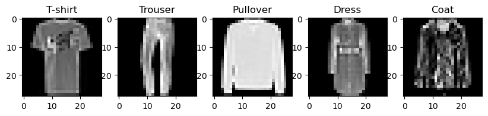

```python
fig, ax = plt.subplots(1, n_classes, figsize=(10,10))

idxs = [np.where(y == i)[0] for i in range(n_classes)]

for i in range(n_classes):
    k = np.random.choice(idxs[i])
    ax[i].imshow(X[k].reshape(28, 28), cmap="gray")
    ax[i].set_title("{}".format(labels[i]))

plt.show()
```

**Implementació:**

Dividiu el *dataset* en dos subconjunts, *train* (80% de les dades) i *test* (20% de les dades). Nombreu els conjunts com: X_train, X_test, y_train, y_test. Utilitzeu l’opció `random_state = 24`.

Podeu utilitzar la implementació `train_test_split` de `sklearn`.

**Solució:**

```python
X_train, X_test, y_train, y_test = train_test_split(
    X, y, test_size=0.2, random_state=24)
```

Per tal de visualitzar els resultats de cada algorisme supervisat, reduirem el dataset anterior a dues dimensions.

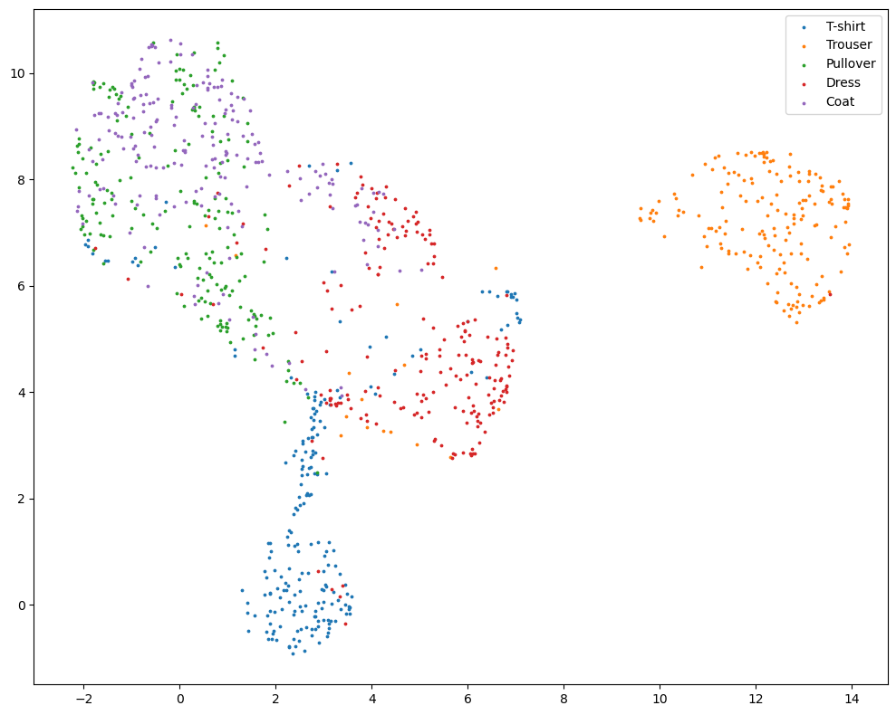

```python
model = umap.UMAP(n_components=2, random_state=42)
model.fit(X_train)
X_train_projection = model.transform(X_train)
X_test_projection = model.transform(X_test)

fig, ax = plt.subplots(1, 1, figsize=(10, 8))
for i in range(n_classes):
    ax.scatter(X_test_projection[y_test == i,0], X_test_projection[y_test == i,1], s=3, label=labels[i])
plt.legend()
plt.tight_layout()
plt.show()
```

Al llarg dels exercicis aprendrem a visualitzar gràficament les fronteres de decisió que ens retornen els diferents models. Per fer-ho, utilitzarem la funció definida a continuació, que segueix els passos següents:

1. Crear una meshgrid amb els valors mínim i màxim de 'x' i 'y'.
2. Predir el classificador amb els valors de la meshgrid.
3. Fer un reshape de les dades per obtenir el format corresponent.
4. Un cop fet això, ja podem generar el gràfic de les fronteres de decisió i afegir-hi els punts reals. Així veurem les àrees que el model considera que són d'una classe i les que considera que són d'una altra. Quan hi superposem els punts, podrem comprovar si els classifica correctament dins l'àrea que els correspon.

```python
# Create the meshgrid with the minimum and maximum values of the x and y axes
x_min, x_max = X_test_projection[:, 0].min() - 1, X_test_projection[:, 0].max() + 1
y_min, y_max = X_test_projection[:, 1].min() - 1, X_test_projection[:, 1].max() + 1

# Define the function that will visualize the decision boundary
def plot_decision_boundaries(model, X_test_projection, y_test):

    xx, yy = np.meshgrid(np.arange(x_min, x_max, 0.05),
                         np.arange(y_min, y_max, 0.05))

    # Prediction by using all values of the meshgrid
    Z = model.predict(np.c_[xx.ravel(), yy.ravel()])

    # Define the colors (one for each class)
    cmap_light = ListedColormap(['gainsboro','lightgreen','peachpuff','lightcyan', 'pink'])
    cmap_bold = ['grey','g','sandybrown','c','palevioletred']

    # Draw the borders
    Z = Z.reshape(xx.shape)
    plt.figure(figsize=(20,10))
    plt.pcolormesh(xx, yy, Z, cmap=cmap_light)

    # Draw the points
    for i in range(n_classes):
         plt.scatter(X_test_projection[y_test == i,0], X_test_projection[y_test == i,1],
                     s=3, label=labels[i], c=cmap_bold[i])
    plt.legend()
    plt.xlim(xx.min(), xx.max())
    plt.ylim(yy.min(), yy.max())
    plt.show()
```

## 1.2. Gaussian Naïve Bayes (1 punt)

El propòsit d’aquest primer exercici és comprendre el funcionament de l’algorisme Naïve-Bayes, un algorisme peculiar que es basa en el teorema de Bayes per calcular la probabilitat que una observació pertanyi a cadascuna de les classes. Aquest model assumeix que les característiques d’entrada són independents entre si, fet que permet simplificar el càlcul de les probabilitats condicionals.

**Implementació:**

1. **Entrena un Model de Naïve-Bayes:** Utilitza el conjunt de dades de *train* per entrenar un model de Naïve-Bayes. Fes servir el classificador `GaussianNB` de la biblioteca `sklearn` per a aquest objectiu.
2. **Calcula l'*Accuracy* del Model:** Un cop entrenat el model, calcula la seva precisió (*accuracy*) tant en el conjunt de *train* com en el de *test*. Això et permetrà avaluar com de bé està funcionant el teu model.
3. **Calcula la Matriu de Confusió:** Utilitza el conjunt de *test* per calcular la matriu de confusió del model. Aquesta matriu t’ajudarà a entendre millor els encerts i errors del teu classificador.
4. **Representa Gràficament la Frontera de Decisió:** Finalment, visualitza la frontera de decisió del model utilitzant el conjunt de *test*. Pots fer això amb l’ajuda de la funció `plot_decision_boundary` que ja has creat prèviament.

Per a realitzar aquests càlculs i visualitzacions, utilitza les funcions `accuracy_score` i `confusion_matrix` del paquet `metrics` de `sklearn`.

**Solució:**

```python
model = GaussianNB()
model.fit(X_train_projection, y_train)
y_pred = model.predict(X_test_projection)
accuracy_test = accuracy_score(y_test, y_pred)
y_pred_train = model.predict(X_train_projection)
accuracy_train = accuracy_score(y_train, y_pred_train)
cfmatrix = confusion_matrix(y_test, y_pred)
print(accuracy_test)
print(accuracy_train)
print(cfmatrix)
```

```
0.726
0.7535
[[167   0  13  28   4]
 [  2 171   2  11   0]
 [ 11   0 156   0  27]
 [ 23   1   6 159  16]
 [  7   0 111  12  73]]
```

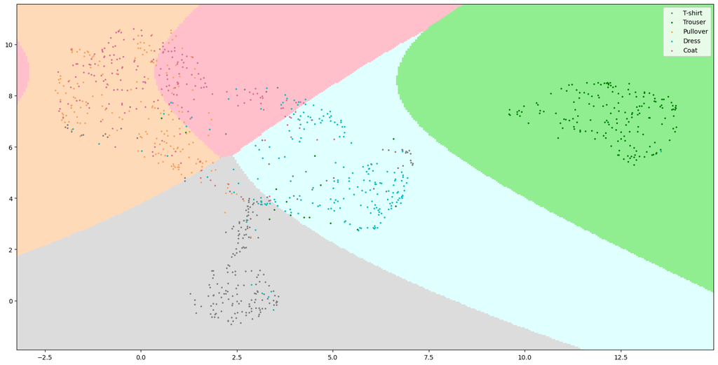

```python
plot_decision_boundaries(model, X_test_projection, y_test)
```

**Anàlisi:**

Anàlisi de l'exercici.

- Com són les fronteres de decisió? Té sentit que tinguin aquesta forma amb l'algorisme utilitzat?
- Com són les prediccions obtingudes sobre el conjunt de test?

**Resposta:**

Naive Bayes suposa que tots els predictors són independents, la qual cosa condueix a una covariància zero entre ells. Aquesta forta suposició simplifica significativament els càlculs, fent que Naive Bayes sigui eficient computacionalment. En el nostre cas en concret estem utilitzant Gaussian NB per tant asumim que els valors coninuus estan repartits d'acord a una distribuccio normal o gaussiana, si mirem el dibuix veiem que les fronteres tenen forma de normal girada cap a la dreta, en la que es veu mes clara es en la verda, per tant es la forma que esperariem. Les prediccions son limitades ja que estem asumint moltes coses que no podem confirmar, com que les variables son independents o que la distribucio de les dades es normal, per tant acabem amb una preccicio del 72% amb alguns grups molt millor clasificats que d'altres ja que la distribucio de dades es clarament no normal. També tenim molta disparitat entre la clasificaccio de clases, trourser esta molt ben clasificada en canvi coat esta bastant malament, on tenim més malt clasificats que ben clasificats. Però, tenim una bona aproximacio utilitzant un metodè molt sencill i molt eficient, per tant en determinats casos podria ser suficient.

## 1.3 Anàlisi Discriminant Lineal (LDA) i Anàlisi Discriminant Quadràtic (QDA) (1 punt)

Ara analitzaràs dos algorismes que es basen en la transformació lineal de les característiques d’entrada per maximitzar la separació entre les classes. Aquests models operen sota la suposició que les característiques segueixen una distribució gaussiana. Això et permetrà calcular les probabilitats condicionals de cada classe. Amb aquests càlculs, assignaràs a cada observació la classe que presenti la probabilitat condicional més gran.

**Implementació:**

Segueix aquests passos amb el dataset d’entrenament (*train*):

1. Entrena un model d’Anàlisi Discriminant Lineal (LDA) utilitzant el classificador `LinearDiscriminantAnalysis` de `sklearn`.
2. Calcula l’*accuracy* (precisió) del model tant en les dades de *train* com de *test*.
3. Calcula la matriu de confusió utilitzant les dades de *test*.
4. Representa gràficament la frontera de decisió amb les dades de *test*.

Aquestes accions t’ajudaran a avaluar l’eficàcia del model LDA en el teu conjunt de dades i a entendre millor com classifica les observacions.

**Solució:**

```python
model = LinearDiscriminantAnalysis()
model.fit(X_train_projection, y_train)
y_pred = model.predict(X_test_projection)
accuracy_test = accuracy_score(y_test, y_pred)
y_pred_train = model.predict(X_train_projection)
accuracy_train = accuracy_score(y_train, y_pred_train)
cfmatrix = confusion_matrix(y_test, y_pred)
print(accuracy_test)
print(accuracy_train)
print(cfmatrix)
```

```
0.737
0.755
[[164   0  14  30   4]
 [  3 171   2  10   0]
 [  9   0 135   0  50]
 [ 19   1   6 166  13]
 [  4   0  81  17 101]]
```

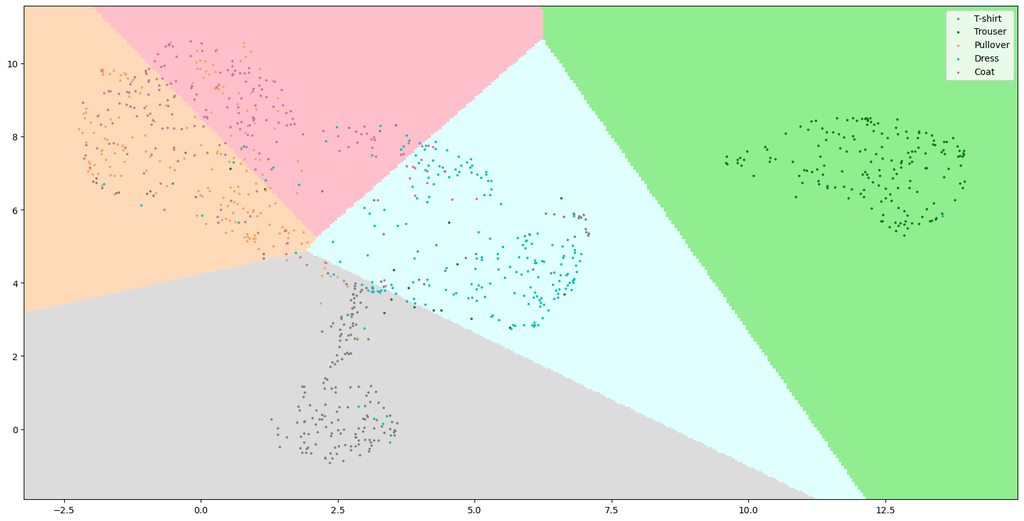

```python
plot_decision_boundaries(model, X_test_projection, y_test)
```

**Anàlisi:**

1. Observa les fronteres de decisió que has generat. Reflexiona sobre la seva forma: s’ajusten al que esperaries de l’algorisme d’Anàlisi Discriminant Lineal (LDA)? Considera la naturalesa lineal de l’algorisme i com això influeix en la forma de les fronteres.
2. Avalua les prediccions realitzades sobre el conjunt de test. Analitza la seva precisió i com es distribueixen respecte a les fronteres de decisió. Són coherents aquestes prediccions amb el que observes a les fronteres de decisió?

Aquestes reflexions et permetran comprendre millor l’efectivitat del model LDA i la seva adequació per al conjunt de dades amb què estàs treballant.

**Resposta:**

LDA,també esta bastat en el teorema de bayes pero, assumeix que els predictors es distribueixen normalment i que totes les classes comparteixen la mateixa matriu de covariància. Aquesta suposició condueix a límits de decisió lineals. Per tant tenim separat els grups de forma lineal com veiem clarament a la imatge. Tenim un problema similar a abans que asumim coses per poder utilitzar aquest algoritme, i tenim una accurarcy similar, en aquest cas sembla que una separacio lineal es una mica més similar a nb però no crec que sigui una diferencia significativa encara que la clase de coat veiem una millora sustacial a la cm ja que ara la categoria mes poblada es la correcta

**Implementació:**

Realitza els passos següents amb el dataset d’entrenament (*train*):

1. Entrena un model d’Anàlisi Discriminant Quadràtic (QDA) utilitzant el classificador `QuadraticDiscriminantAnalysis` de `sklearn`.
2. Calcula l’*accuracy* (precisió) del model tant en les dades de *train* com en les de *test*.
3. Calcula la matriu de confusió utilitzant les dades de *test*.
4. Representa gràficament la frontera de decisió amb les dades de *test*.

Aquests passos t’ajudaran a avaluar com el model QDA es comporta amb el teu conjunt de dades i a entendre la seva capacitat per classificar i diferenciar entre les classes.

**Solució:**

```python
model = QuadraticDiscriminantAnalysis()
model.fit(X_train_projection, y_train)
y_pred = model.predict(X_test_projection)
accuracy_test = accuracy_score(y_test, y_pred)
y_pred_train = model.predict(X_train_projection)
accuracy_train = accuracy_score(y_train, y_pred_train)
cfmatrix = confusion_matrix(y_test, y_pred)
print(accuracy_test)
print(accuracy_train)
print(cfmatrix)
```

```
0.721
0.74225
[[166   0  14  28   4]
 [  3 171   2  10   0]
 [  8   0 139   0  47]
 [ 27   1   7 156  14]
 [  6   0  95  13  89]]
```

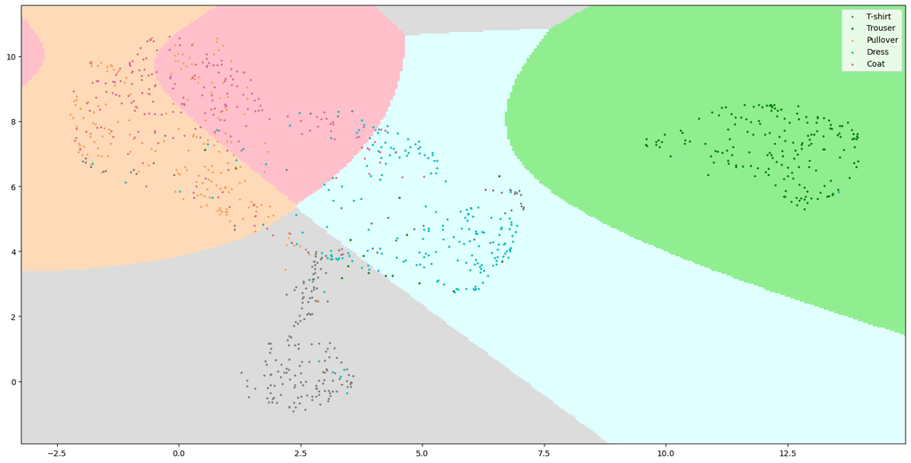

```python
plot_decision_boundaries(model, X_test_projection, y_test)
```

**Anàlisi:**

1. Examina les fronteres de decisió que has generat. Reflexiona sobre la seva forma: és coherent amb el que esperaries de l’algorisme d’Anàlisi Discriminant Quadràtic (QDA)? Considera com la naturalesa quadràtica de l’algorisme podria influir en la forma d’aquestes fronteres.
2. Avalua les prediccions realitzades sobre el conjunt de test. Observa la seva precisió i com es distribueixen en relació amb les fronteres de decisió. Són aquestes prediccions consistents amb les fronteres observades?
3. Reflexiona sobre les diferències entre els algorismes LDA i QDA. En què es diferencien en termes de supòsits, enfocament i resultats en les teves dades?

Aquesta anàlisi et permetrà comprendre les característiques i l’eficàcia de tots dos models, LDA i QDA, i com s’apliquen al teu conjunt de dades.

**Resposta:**

QDA amplia això relaxant el supòsit de covariància compartida, permetent que cada classe tingui la seva pròpia matriu de covariància, donant lloc a límits de decisió quadràtics. Que es el que veiem a la imatge Les prediccions tenen un ordre similar per totes ja que estan basades en distribcions normals i bayes, en aquest cas tornem a veure com abans que segons la cm de coat tenim més mal clasificats que ben clasificats, sembla que es la categoria més dificil de clasificar per aquests models

Si les comparem entre les tres tenim que Naive Bayes és computacionalment eficient i funciona bé per a dades d'alta dimensió o quan la independència entre els predictors és raonable. Tanmateix, la seva forta hipòtesi d'independència pot limitar el seu rendiment quan els predictors estan altament correlacionats. LDA és més robust en el maneig de predictors correlacionats i ofereix un millor rendiment quan es compleixen les seves hipòtesis. Tanmateix, suposa una covariància igual entre les classes, cosa que potser no sempre és realista. QDA, sent més flexible, sovint supera l'LDA en els casos en què les covariàncies de classe difereixen, però requereix més dades per estimar matrius de covariància separades de manera fiable.

## 1.4. KNN (1 punt)

En aquest punt, entendràs el funcionament de l’algorisme KNN (K-Nearest-Neighbor), que es basa en la proximitat dels punts de dades en un espai de característiques. Analitzaràs els seus avantatges i desavantatges, i comprendràs com els paràmetres que el componen influeixen en el seu comportament.

KNN és un algorisme de tipus supervisat basat en instància. Això significa:

- Supervisat: El teu conjunt de dades d’entrenament està etiquetat amb la classe o resultat esperat.
- Basat en instància (*Lazy Learning*): L’algorisme no aprèn explícitament un model, com en la Regressió Logística o els arbres de decisió. En canvi, memoritza les instàncies d’entrenament i les utilitza com a "coneixement" en la fase de predicció.

Per entendre com funciona KNN, segueix aquests passos:

1. Calcula la distància entre l’ítem a classificar i la resta d’ítems del dataset d’entrenament.
2. Selecciona els "k" elements més propers, és a dir, aquells amb la menor distància, segons el tipus de distància que utilitzis (euclidiana, cosinus, manhattan, etc).
3. Realitza una "votació de majoria" entre els k punts seleccionats: la classe que predomini en aquests punts decidirà la classificació final de l’ítem analitzat.

**Implementació:**

Realitza els passos següents amb el dataset d’entrenament (*train*):

1. Entrena un classificador KNN amb l’hiperparàmetre `n_neighbors=2` utilitzant el classificador `KNeighborsClassifier` de `sklearn`.
2. Calcula l’*accuracy* (precisió) del model tant en les dades de *train* com en les de *test*.
3. Calcula la matriu de confusió utilitzant les dades de *test*.
4. Representa gràficament la frontera de decisió amb les dades de *test*.

Si en entrenar el classificador apareix un avís (*warning*) i vols ignorar-lo, executa el codi següent abans de l’entrenament:

`import warnings`  
`warnings.filterwarnings('ignore', message='^.*will change.*$', category=FutureWarning)`

Això et permetrà avaluar l’efectivitat del model KNN amb `n_neighbors=2` en el teu conjunt de dades i entendre com es comporta en termes de classificació i separació de classes.

**Solució:**

```python
model = KNeighborsClassifier(n_neighbors=2)
model.fit(X_train_projection, y_train)
y_pred = model.predict(X_test_projection)
accuracy_test = accuracy_score(y_test, y_pred)
y_pred_train = model.predict(X_train_projection)
accuracy_train = accuracy_score(y_train, y_pred_train)
cfmatrix = confusion_matrix(y_test, y_pred)
print(accuracy_test)
print(accuracy_train)
print(cfmatrix)
```

```
0.733
0.8765
[[186   1   8  12   5]
 [  3 173   1   9   0]
 [  9   6 140   4  35]
 [ 26   9  19 142   9]
 [  7   3  92   9  92]]
```

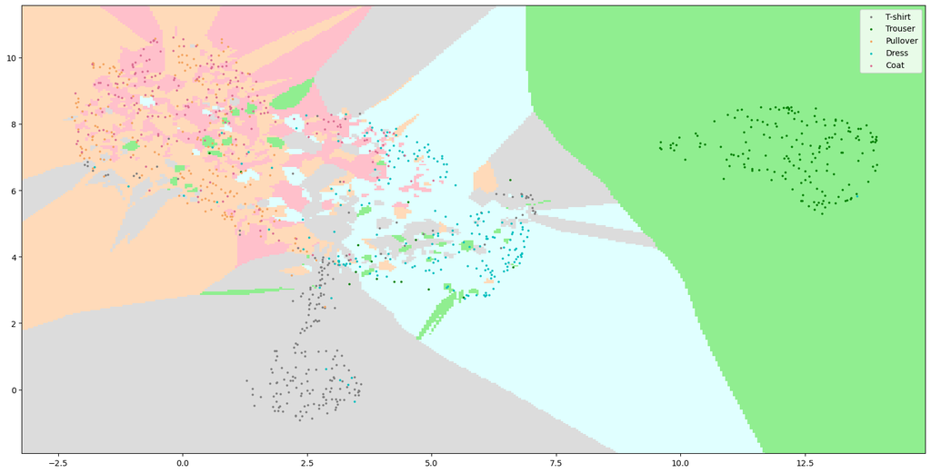

```python
plot_decision_boundaries(model, X_test_projection, y_test)
```

En el model que has entrenat, has fixat el paràmetre `n_neighbors` de manera arbitrària. Tanmateix, és possible que amb un altre valor obtinguis una millor predicció. Per trobar el valor òptim dels paràmetres d’un model (*hyperparameter tuning*), sovint s’utilitza una cerca de graella (*grid search*). Això implica entrenar un model per a cada combinació possible d’hiperparàmetres i avaluar-lo mitjançant validació creuada (*cross validation*) amb 5 particions estratificades. Posteriorment, seleccionaràs la combinació d’hiperparàmetres que hagi obtingut els millors resultats.

En aquest cas, et centraràs en optimitzar un sol hiperparàmetre:

- 𝑘: el nombre de veïns que es consideren per classificar un nou exemple. Has de provar amb tots els valors entre 1 i 20.

Realitza aquest procés per identificar el nombre òptim de veïns, fet que et permetrà millorar la precisió de les teves prediccions amb el model KNN.

**Implementació:**

Per calcular el valor òptim de l’hiperparàmetre *k* (`n_neighbors`), has de realitzar una cerca de graella amb validació creuada. Aquest procés t’ajudarà a trobar el valor òptim de *k*. Per a cada valor, calcula la seva mitjana i desviació estàndard. Després, implementa un *heatmap* per visualitzar la precisió segons els diferents valors de l’hiperparàmetre.

Utilitza el mòdul `GridSearchCV` de `sklearn` per calcular el millor hiperparàmetre. Per a la visualització del *heatmap*, fes servir la biblioteca `Seaborn`.

Aquests passos et permetran identificar de manera efectiva i visual el valor de *k* que maximitza la precisió del teu model KNN.

**Solució:**

```python
model = KNeighborsClassifier()
k_range = list(range(2, 25))
param_grid = dict(n_neighbors=k_range)
grid = GridSearchCV(model, param_grid)
grid.fit(X_test_projection, y_test)
```

```
GridSearchCV(estimator=KNeighborsClassifier(),
             param_grid={'n_neighbors': [2, 3, 4, 5, 6, 7, 8, 9, 10, 11, 12, 13,
                                         14, 15, 16, 17, 18, 19, 20, 21, 22, 23,
                                         24]})
```

```python
mean_test_score = grid.cv_results_["mean_test_score"]
std_test_score = grid.cv_results_["std_test_score"]
```

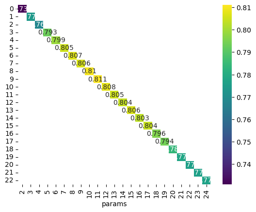

```python
grid_results = pd.DataFrame(grid.cv_results_)
grid_results["params"] = grid_results["params"].apply(lambda x: x["n_neighbors"])
result = grid_results.pivot( columns='params', values='mean_test_score')

sns.heatmap(result, annot=True, fmt="g", cmap='viridis')
plt.show()
```

**Implementació:**

Segueix aquests passos amb el dataset d’entrenament (*train*):

1. Entrena un classificador KNN utilitzant el millor hiperparàmetre que hagis trobat.
2. Calcula l’*accuracy* (precisió) del model tant en les dades de *train* com en les de *test*.
3. Calcula la matriu de confusió utilitzant les dades de *test*.
4. Representa gràficament la frontera de decisió amb les dades de *test*.

Aquest procés et permetrà veure com l’hiperparàmetre òptim que has identificat millora l’eficàcia del teu model KNN en la classificació de les dades.

**Solució:**

```python
model = KNeighborsClassifier(n_neighbors=11)
model.fit(X_train_projection, y_train)
y_pred = model.predict(X_test_projection)
accuracy_test = accuracy_score(y_test, y_pred)
y_pred_train = model.predict(X_train_projection)
accuracy_train = accuracy_score(y_train, y_pred_train)
cfmatrix = confusion_matrix(y_test, y_pred)
print(accuracy_test)
print(accuracy_train)
print(cfmatrix)
```

```
0.78
0.83375
[[181   0   7  18   6]
 [  3 171   0  10   2]
 [  5   0 126   0  63]
 [ 12   1  10 164  18]
 [  1   0  54  10 138]]
```

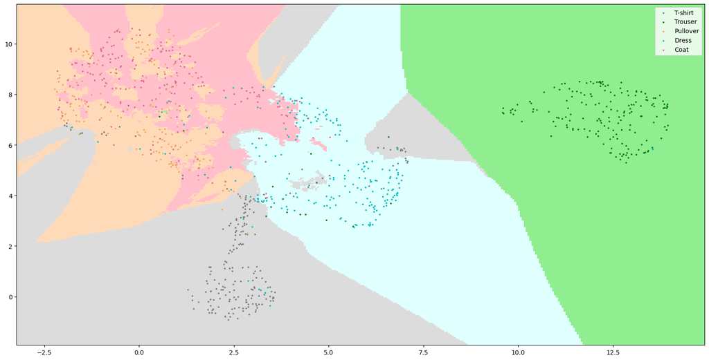

```python
plot_decision_boundaries(model, X_test_projection, y_test)
```

**Anàlisi:**

1. Comenta els resultats obtinguts en la cerca del millor hiperparàmetre. Reflexiona sobre com ha variat el rendiment del model amb els diferents valors de `n_neighbors`.
2. Analitza com es visualitza gràficament el canvi del valor de `n_neighbors`. Observes alguna tendència o patró clar? És coherent aquesta diferència entre els dos gràfics quan canvia el paràmetre?
3. Examina les fronteres de decisió que has generat. Té sentit la forma d’aquestes fronteres donat l’algorisme KNN utilitzat? Pensa en com l’elecció del nombre de veïns influeix en la forma de la frontera.
4. Avalua les prediccions realitzades sobre el conjunt de test. Observa la seva precisió i com es distribueixen en relació amb les fronteres de decisió. Són aquestes prediccions consistents amb el que observes a les fronteres de decisió?

Aquesta anàlisi t’ajudarà a comprendre l’eficàcia del model KNN amb diferents configuracions de `n_neighbors` i el seu impacte en la classificació de les dades.

**Resposta:**

Contra més baixem el valor de n_neighbors menys notarem el sorroll pero també correm el risk de overfitegar molt a les dades de entrenament, en canvi si el fem més gran el sobreentrenament es menys probable però es podem perdre detakkm per tant té sentit que el millor model estigui en un punt mitg

Quan la el nuemero de veins es més petit veiem que els grups estan mes fragmentats, això es degut a que es pred generalitat i ens apropem més a les dades d'entrenament crec que això es totalment logic ja que amb menys veins a comparar es més probable fragmentar més les clases

Les fronteres tenen sentit ja que tens els valors mes propers als punts del colors dels punts com tenim barreja a certes zones tindrem fronteres fragmentades

Aquest metode te una millora sustancial respecte els altres i això es degut a que no suposem res de les dades, el problema principal que te es que nomes depenem de la distancia entre n veins per decidir la clase que tenim per tant quan tenim dos grups superposats li es dificil decidir a quin va quin com en el grup de coat, però es el millor metode que hem vist fins ara

## 1.5. SVM (1 punt)

En aquesta secció, exploraràs les Màquines de Vectors de Suport (SVM), que es basen en el concepte del *Maximal Margin Classifier* i l’hiperplà.

Un hiperplà en un espai p-dimensional es defineix com un subespai pla i afí de dimensions p-1. En dues dimensions, és una recta; en tres, un pla convencional. Per a dimensions majors a tres, encara que no sigui intuïtiu de visualitzar, el concepte es manté.

Quan els casos són perfectament separables de manera lineal, sorgeixen infinits possibles hiperplans. Per seleccionar el classificador òptim, utilitza el concepte de *maximal margin hyperplane*, l’hiperplà que es troba més allunyat de totes les observacions d’entrenament. Aquest es defineix calculant la distància perpendicular mínima (marge) de les observacions a un hiperplà. L’hiperplà òptim és aquell que maximitza aquest marge.

En el procés d’optimització, has de tenir en compte que només les observacions al marge o que el violen (vectors suport) influeixen en l’hiperplà. Aquests vectors suport són els que defineixen el classificador.

#### Els *kernels* en SVM

En situacions on no pots trobar un hiperplà que separi dues classes, és a dir, quan les classes no són linealment separables, pots utilitzar el truc del nucli (*kernel trick*). Aquest mètode et permet treballar en una dimensió nova on és possible trobar un hiperplà per separar les classes.

Igual que amb el KNN, les SVM també depenen de diversos hiperparàmetres. En aquest cas, et centraràs en optimitzar dos hiperparàmetres:

1. **C**: la regularització, que és el valor de penalització dels errors en la classificació. Aquest valor indica el compromís entre obtenir l’hiperplà amb el marge més gran possible i classificar correctament el màxim nombre d’exemples. Has de provar els valors següents: 0.01, 0.1, 1, 10, 50, 100 i 200.
2. **Gamma**: un coeficient que multiplica la distància entre dos punts en el kernel radial. En termes simples, com més petit sigui gamma, més influència tindran dos punts propers. Has de provar els valors: 0.001, 0.01, 0.1, 1 i 10.

Per validar el rendiment de l’algorisme amb cada combinació d’hiperparàmetres, utilitza la validació creuada (*cross-validation*) amb 4 particions estratificades.

**Implementació:**

1. Calcula el valor òptim dels hiperparàmetres *C* i *gamma* utilitzant una cerca de graella amb validació creuada. Aquest procés t’ajudarà a trobar els valors òptims.
2. Per a cada combinació de valors, calcula la seva mitjana i desviació estàndard.
3. Fes un *heatmap* per visualitzar la precisió segons els diferents valors dels hiperparàmetres.

Utilitza el mòdul `GridSearchCV` de `sklearn` per calcular els millors hiperparàmetres amb el classificador SVC (de `SVM` de `sklearn`). Per a la visualització del *heatmap*, fes servir la biblioteca `Seaborn`.

Aquests passos et permetran identificar de manera efectiva i visual els valors de *C* i *gamma* que maximitzen la precisió del teu model SVM.

**Solució:**

```python
model = SVC()
param_grid = {'C': [0.01, 0.1, 1, 10, 50, 100 , 200],
          'gamma': [0.001, 0.01, 0.1, 1 , 10]}
grid = GridSearchCV(model, param_grid)
grid.fit(X_test_projection, y_test)
```

```
GridSearchCV(estimator=SVC(),
             param_grid={'C': [0.01, 0.1, 1, 10, 50, 100, 200],
                         'gamma': [0.001, 0.01, 0.1, 1, 10]})
```

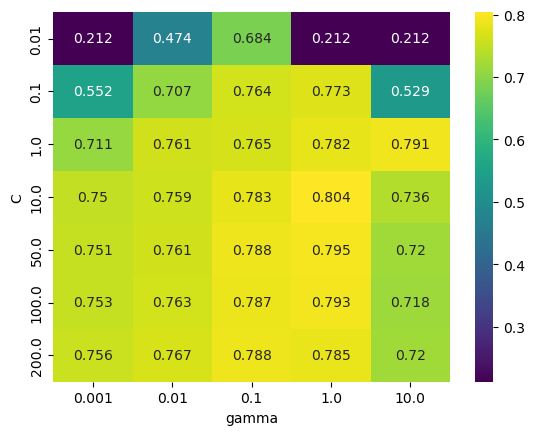

```python
grid_results = pd.DataFrame(grid.cv_results_)
grid_results["C"] = grid_results["params"].apply(lambda x: x["C"])
grid_results["gamma"] = grid_results["params"].apply(lambda x: x["gamma"])
result = grid_results.pivot( index="C",columns='gamma', values='mean_test_score')

sns.heatmap(result, annot=True, fmt="g", cmap='viridis')
plt.show()
```

**Implementació:**

Realitza els passos següents amb el dataset d’entrenament (*train*):

1. Entrena un model SVM utilitzant la millor combinació de paràmetres que hagis trobat.
2. Calcula l’*accuracy* (precisió) del model tant en les dades de *train* com en les de *test*.
3. Calcula la matriu de confusió utilitzant les dades de *test*.
4. Representa gràficament la frontera de decisió amb les dades de *test*.

Aquest procés et permetrà veure com la millor combinació de paràmetres millora l’eficàcia del teu model SVM en la classificació de les dades.

**Solució:**

```python
model = SVC(C=10, gamma=1)
model.fit(X_train_projection, y_train)
y_pred = model.predict(X_test_projection)
accuracy_test = accuracy_score(y_test, y_pred)
y_pred_train = model.predict(X_train_projection)
accuracy_train = accuracy_score(y_train, y_pred_train)
cfmatrix = confusion_matrix(y_test, y_pred)
print(accuracy_test)
print(accuracy_train)
print(cfmatrix)
```

```
0.784
0.81775
[[177   0   8  21   6]
 [  2 171   0  11   2]
 [  5   0 130   0  59]
 [ 19   1   6 161  18]
 [  1   0  47  10 145]]
```

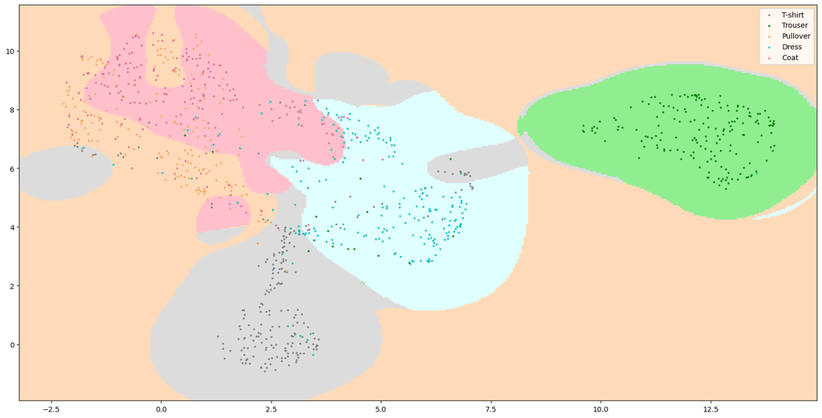

```python
plot_decision_boundaries(model, X_test_projection, y_test)
```

**Anàlisi:**

1. Comenta els resultats obtinguts en la cerca dels millors hiperparàmetres. Reflexiona sobre com ha variat el rendiment del model SVM amb els diferents valors de *C* i *gamma*. Considera si els valors òptims trobats tenen sentit en el context del teu conjunt de dades.
2. Examina les fronteres de decisió que has generat amb el model SVM. És coherent la forma d’aquestes fronteres amb el que esperaries de l’algorisme utilitzat? Pensa en com la combinació d’hiperparàmetres seleccionats podria influir en la forma de les fronteres.
3. Avalua les prediccions realitzades sobre el conjunt de test. Observa la seva precisió i com es distribueixen en relació amb les fronteres de decisió. Són aquestes prediccions consistents amb el que observes a les fronteres de decisió?

Aquesta anàlisi t’ajudarà a comprendre l’eficàcia del model SVM amb els hiperparàmetres seleccionats i el seu impacte en la classificació de les dades.

**Resposta:**

Hem obtingut els millors resultats amb C=10, gamma=1 com no hem especificat kernel de base utilitzem el rbf, si mirem la documentació del kernel rbf a l'hora de possar hiperparameteres veiem que Intuïtivament, el paràmetre gamma defineix fins a quin punt arriba la influència d'un únic exemple d'entrenament, amb valors baixos que signifiquen "lluny" i valors alts que signifiquen "a prop". Els paràmetres gamma es poden veure com la inversa del radi d'influència de les mostres seleccionades pel model com a vectors de suport.

El paràmetre C compensa la classificació correcta dels exemples d'entrenament amb la maximització del marge de la funció de decisió. Per a valors més grans de C, s'acceptarà un marge més petit si la funció de decisió és millor per classificar correctament tots els punts d'entrenament. Una C més baixa fomentarà un marge més gran, per tant una funció de decisió més senzilla, a costa de la precisió de l'entrenament. En altres paraules, C es comporta com un paràmetre de regularització a l'SVM.

Tenint en compte això fa sentit que gama sigui relaitvament alta ja que volem punts aprop sobretot en la part on tenim molts punts sobreposats i la C esta al mitg fent un trade of entre entrenament i test.

Les fronteres de decisio sembla que no tenen sentit pero recordem que hem projectat a mes dimensions i despres hem tornat a dos per tant al tornar a dos dimesions coses que abans estaben a prop ara poden estar lluny per això dona la sensasio que les agripacions no tenen molt senit.

Les prediccions tenen sentit amb les fornteres les quals son projecions de mes dimenison en dos que ens permet captar punts que d'una altre manera seria complicat

## 1.6. Arbres de decisió (1 punt)

En aquesta secció, exploraràs els arbres de decisió, models predictius que es basen en regles binàries (sí/no) per classificar les observacions segons els seus atributs i predir el valor de la variable resposta. Aquests arbres poden ser classificadors, com en el teu exemple, o regressors per predir variables contínues.

#### Construcció d’un Arbre

Per construir un arbre, segueix l’algorisme de *recursive binary splitting*:

1. Comença a la part superior de l’arbre, on totes les observacions pertanyen a la mateixa regió.
2. Identifica tots els possibles punts de tall per a cadascun dels predictors. Aquests punts de tall són els diferents nivells dels predictors.
3. Avalua les possibles divisions per a cada predictor utilitzant una mesura específica. En els classificadors, aquestes mesures poden ser el *classification error rate*, l’índex Gini, l’entropia o el chi-square.

Comprendre aquests passos t’ajudarà a entendre com els arbres de decisió creen divisions binàries per classificar les dades i com es poden aplicar tant per a classificació com per a regressió.

**Implementación:**

Sigue estos pasos:

1. Con el dataset de entrenamiento (*train*), entrena un árbol de decisión utilizando el clasificador `DecisionTreeClassifier` de la biblioteca `tree` de `sklearn`.
2. Calcula el *accuracy* (precisión) del modelo tanto en los datos de *train* como de *test*.
3. Calcula la matriz de confusión utilizando los datos de *test*.
4. Representa gráficamente la frontera de decisión con los datos de *test*.
5. Representa el árbol de decisión. Puedes utilizar el comando `plot.tree` de la biblioteca `tree` de `sklearn`.

Estos pasos te permitirán evaluar cómo el árbol de decisión se comporta en tu conjunto de datos, tanto en términos de clasificación como en su representación visual."

**Solució:**

```python
model = DecisionTreeClassifier()
model.fit(X_train_projection, y_train)
y_pred = model.predict(X_test_projection)
accuracy_test = accuracy_score(y_test, y_pred)
y_pred_train = model.predict(X_train_projection)
accuracy_train = accuracy_score(y_train, y_pred_train)
cfmatrix = confusion_matrix(y_test, y_pred)
print(accuracy_test)
print(accuracy_train)
print(cfmatrix)
```

```
0.74
1.0
[[172   3  12  20   5]
 [  2 169   2  11   2]
 [  6   1 119   3  65]
 [ 14   3   9 162  17]
 [  5   2  68  10 118]]
```

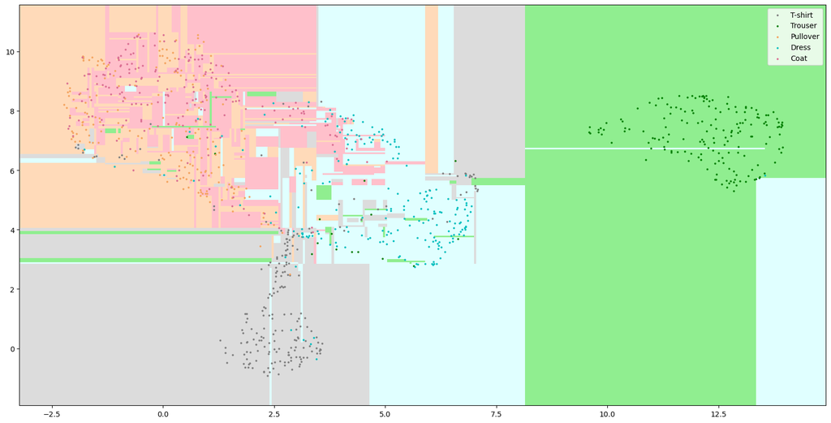

```python
plot_decision_boundaries(model, X_test_projection, y_test)
```

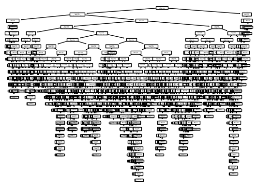

```python
tree.plot_tree(model)
plt.show()
```

**Anàlisi:**

1. **Avalua i comenta els resultats:** Analitza l’*accuracy* del model en els conjunts de *train* i *test*. Si el model té un *accuracy* molt alt en *train* però significativament més baix en *test*, això pot indicar overfitting. A més, revisa la matriu de confusió per identificar si hi ha desequilibris en les classificacions correctes i errors per classe.
2. **Reflexiona sobre la frontera de decisió:** Observa si la frontera de decisió al conjunt de *test* mostra patrons abruptes o sobrecomplexos. Aquesta característica és coherent amb el que esperaries d’un arbre de decisió, especialment si està profundament ajustat al conjunt de *train*.
3. **Observa la representació gràfica de l’arbre:** Analitza com les ramificacions mostren les decisions preses pel model. Busca si hi ha nodes fulla amb un nombre molt reduït d’observacions o divisions molt específiques que podrien indicar sobreajustament. Comprova si les regles de classificació són intuïtives i si reflecteixen els patrons esperats en el conjunt de dades.

Aquesta anàlisi t’ajudarà a identificar possibles ajustaments al model per millorar la seva capacitat de generalització i la seva eficàcia global.

**Resposta:**

Al ser un abre complet tindrem en train una accuracy perfecta per això clarament hem caigut en overfiting i a la cm veiem que els pitjos parats d'aques overfiting son coat i pullover

Veiem que la separacio entre clases es bastant complexa però aixo es degut a que hem clasificat tots els punts d'entrenamet al arribar a una abre complet donant un aspecte molt irregular amb fulles amb pocs elements inclus tenit fulles amb un sol element. per evitar això podem quedarnos amb menys profunditat i amb un nombre minim de fulles

#### Evitant el *overfitting*

El procés de construcció d’arbres descrit tendeix a reduir ràpidament l’error d’entrenament, de manera que, generalment, el model s’ajusta molt bé a les observacions utilitzades com a entrenament (conjunt de *train*). Com a conseqüència, els arbres de decisió tendeixen a l’*overfitting*.

Per evitar l’*overfitting* en els arbres de decisió, és crucial que modifiquis certs hiperparàmetres del model de la manera següent:

1. Utilitza l’hiperparàmetre `max_depth`, que defineix la profunditat màxima de l’arbre. Hauràs d’explorar els valors entre 4 i 10 per trobar l’equilibri adequat entre la complexitat del model i la seva capacitat per generalitzar.
2. Estableix l’hiperparàmetre `min_samples_split`, que és el nombre mínim d’observacions que ha de tenir una fulla de l’arbre abans de considerar una divisió. Experimenta amb valors com 2, 10, 20, 50 i 100 per assegurar-te que l’arbre no es torni massa específic per a les observacions d’entrenament.

Ajustant aquests hiperparàmetres, podràs controlar la tendència de l’arbre de decisió a sobreajustar-se al conjunt d’entrenament, millorant així la seva capacitat per fer prediccions efectives en dades noves.

**Implementació:**

1. Calcula el valor òptim dels hiperparàmetres `max_depth` i `min_samples_split` utilitzant una cerca de graella amb validació creuada. Aquest procés t’ajudarà a trobar els valors òptims que evitaran el sobreajustament.
2. Per a cada combinació de valors, calcula la seva mitjana i desviació estàndard.
3. Fes un *heatmap* per visualitzar la precisió segons els diferents valors dels hiperparàmetres.

Utilitza el mòdul `GridSearchCV` de `sklearn` per calcular els millors hiperparàmetres amb el classificador `DecisionTreeClassifier` de `tree` de `sklearn`. Per a la visualització del *heatmap*, fes servir la biblioteca `Seaborn`.

Aquests passos et permetran identificar de manera efectiva i visual els valors de `max_depth` i `min_samples_split` que maximitzen la precisió del teu arbre de decisió, minimitzant el risc de sobreajustament.

**Solució:**

```python
model = DecisionTreeClassifier()
param_grid = {'max_depth': range(4,11),
          'min_samples_split': [ 2, 10, 20, 50 , 100]}
grid = GridSearchCV(model, param_grid)
grid.fit(X_test_projection, y_test)
```

```
GridSearchCV(estimator=DecisionTreeClassifier(),
             param_grid={'max_depth': range(4, 11),
                         'min_samples_split': [2, 10, 20, 50, 100]})
```

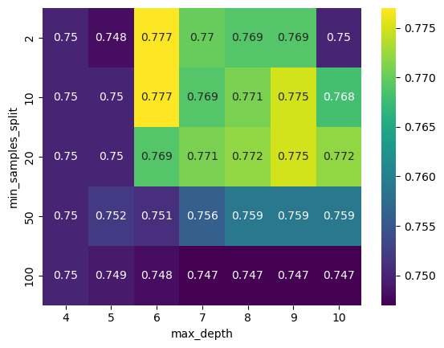

```python
grid_results = pd.DataFrame(grid.cv_results_)
grid_results["max_depth"] = grid_results["params"].apply(lambda x: x["max_depth"])
grid_results["min_samples_split"] = grid_results["params"].apply(lambda x: x["min_samples_split"])
result = grid_results.pivot( index="min_samples_split",columns='max_depth', values='mean_test_score')

sns.heatmap(result, annot=True, fmt="g", cmap='viridis')
plt.show()
```

**Implementació:**

1. Entrena un arbre de decisió amb el dataset d’entrenament (*train*) utilitzant la millor combinació de paràmetres que hagis trobat.
2. Calcula l’*accuracy* (precisió) del model tant en les dades de *train* com en les de *test*.
3. Calcula la matriu de confusió utilitzant les dades de *test*.
4. Representa gràficament la frontera de decisió amb les dades de *test*.
5. Representa l’arbre de decisió.

Aquests passos et permetran avaluar com l’arbre de decisió, ajustat amb els hiperparàmetres òptims, es comporta en el teu conjunt de dades, tant en termes de classificació com en la seva representació visual.

**Solució:**

```python
model = DecisionTreeClassifier(max_depth=6,min_samples_split=10)
model.fit(X_train_projection, y_train)
y_pred = model.predict(X_test_projection)
accuracy_test = accuracy_score(y_test, y_pred)
y_pred_train = model.predict(X_train_projection)
accuracy_train = accuracy_score(y_train, y_pred_train)
cfmatrix = confusion_matrix(y_test, y_pred)
print(accuracy_test)
print(accuracy_train)
print(cfmatrix)
```

```
0.778
0.79025
[[175   0  17  16   4]
 [  2 169   2  13   0]
 [  3   0 121   0  70]
 [ 11   1  17 160  16]
 [  0   0  40  10 153]]
```

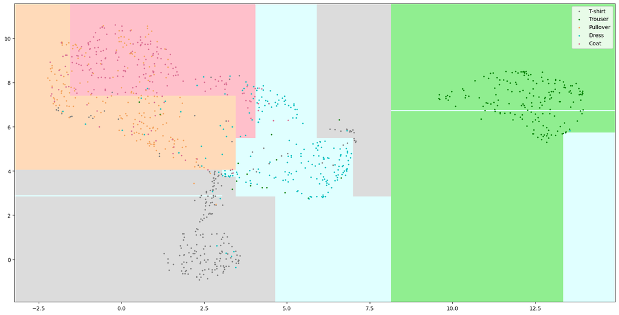

```python
plot_decision_boundaries(model, X_test_projection, y_test)
```

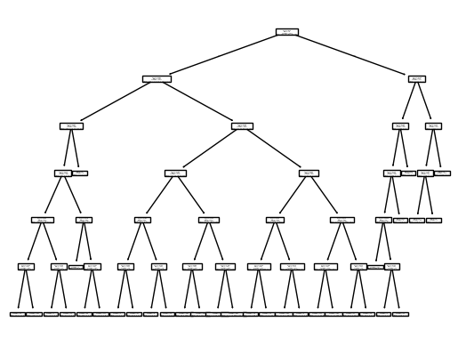

```python
tree.plot_tree(model)
plt.show()
```

**Anàlisi:**

1. Avalua i comenta els resultats obtinguts en la cerca dels millors hiperparàmetres. Considera com la combinació òptima de `max_depth` i `min_samples_split` ha impactat en el rendiment de l’arbre de decisió.
2. Examina les fronteres de decisió generades amb el conjunt de *test*. Reflexiona si la forma d’aquestes fronteres és coherent amb el que esperaries d’un arbre de decisió configurat amb aquests hiperparàmetres.
3. Analitza les prediccions realitzades sobre el conjunt de *test*. Observa la seva precisió i com es distribueixen en relació amb les fronteres de decisió. Són consistents aquestes prediccions amb l’estructura de l’arbre de decisió i les fronteres observades?

Aquesta anàlisi t’ajudarà a comprendre l’eficàcia de l’arbre de decisió amb els hiperparàmetres seleccionats i el seu impacte en la classificació de les dades.

**Resposta:**

Hem hagut de posar un numero minim de fulles per no tindre fulles molt especifiques que no ens ajuden a clasificar ja que nomes tenen un sol element i no caura res allà i max_deph pel mateix, perque trobar caracteristiques més concretes no ens ajudara a generalitzar i fara que s'acosti molt a les dades de entrenament

Ara tenim fronteres més amples, segueixen tenent la mateixa forma, com rectes pero això te senit pel criteri de particio establert, i veiem com cada seccio te dintre varios punts del mateix veient que compleix el minim de fulles en una fulla

# 2. Implementació del cas pràctic (5 punts)

Avui dia, la logística de l’última milla és un problema abordat a la indústria per moltes empreses dedicades al comerç electrònic. La informació proporcionada a l’usuari a l’hora de fer una comanda pot suposar un valor diferencial. Per això, moltes empreses dediquen molts recursos per oferir una estimació precisa sobre el temps que trigarà a arribar cada comanda. En aquest exercici ens centrarem a predir el nivell de servei de les operacions logístiques de l’última milla d’Amazon. En concret, identificarem aquelles entregues que es considerin premium (temps de repartiment inferior a dues hores).

Per fer-ho, utilitzarem el conjunt de dades d’entregues amazon-delivery-dataset, el qual inclou dades sobre més de 43.632 entregues en diverses ciutats, amb informació rellevant sobre els detalls de la comanda, els agents de lliurament, les condicions meteorològiques i del trànsit, i les mètriques de rendiment del lliurament. En concret, el dataset conté 16 característiques:

- Order_ID: identificador únic de comanda
- Agent_Age: edat de l’agent (repartidor)
- Agent_Rating: puntuació de l’agent (repartidor)
- Store_Latitude: latitud del magatzem o botiga
- Store_Longitude: longitud del magatzem o botiga
- Drop_Latitude: latitud del client
- Drop_Longitude: longitud del client
- Order_Date: data de la comanda
- Order_Time: hora de la comanda
- Pickup_Time: hora a la qual la comanda va ser recollida per al seu lliurament
- Weather: informació sobre la climatologia
- Traffic: informació sobre el trànsit
- Vehicle: informació sobre el vehicle
- Area: informació sobre l’àrea de repartiment
- Category: categoria dels productes de la comanda
- Delivery_Time: temps de lliurament (minuts)

L’objectiu d’aquesta secció és abordar l’anàlisi d’aquest conjunt de dades i entrenar una xarxa neuronal (Perceptró Multicapa) per predir el nivell de servei. Aquí tens alguns passos que podries seguir:

## 2.1. Càrrega de dades i processament inicial (0.5 punts)

El primer que has de fer és carregar el conjunt de dades i visualitzar informació rellevant del mateix. Assegura’t de verificar el següent:

1. Confirma la quantitat total de files i columnes al DataFrame.
2. Revisa el nom de cada columna del DataFrame.
3. Verifica el nombre de valors no nuls en cada columna.
4. Identifica el tipus de dades de cada columna, que pot ser int, float, object, entre d’altres.
5. Comprova la quantitat de memòria utilitzada pel DataFrame.

Aquests passos et proporcionaran una comprensió inicial clara i detallada del conjunt de dades amb el qual estàs treballant.

```python
root_path = kagglehub.dataset_download("sujalsuthar/amazon-delivery-dataset")
dataset_path = os.path.join(root_path, "amazon_delivery.csv")
data = pd.read_csv(dataset_path)
```

**Implementació:**

Com es pot observar, no disposem del nivell de servei en el conjunt de dades. Per això, definirem que totes les entregues realitzades en un màxim de dues hores han tingut un servei Premium. Per fer-ho, crea una nova columna denominada "Premium_Delivery", que contingui el valor 1 si l’entrega s’ha realitzat en un màxim de 120 minuts, i un 0 en cas contrari. És important assegurar que el tipus de la nova columna sigui enter.

**Solució:**

```python
def get_sec(time_str):
    """Get seconds from time."""
    if(len(time_str.split(':'))<3):
        return -9999999
    h, m, s = time_str.split(':')
    return int(h) * 3600 + int(m) * 60 + int(s)
def comparator(order,pickup):
    order=get_sec(order)
    pickup=get_sec(pickup)
    if order>pickup:
        pickup=pickup+24*3600
    return -(order -pickup)
data.replace('',np.NaN)
data["Premium_Delivery"] = data.apply(lambda x: 1 if x.Delivery_Time<=120  else 0, axis=1)
```

**Implementació:**

Per simplificar l’exercici i facilitar-ne la comprensió, s’han d’eliminar les següents columnes: Order_ID, Order_Date, Order_Time i Pickup_Time.

**Solució:**

```python
data=data.drop(columns=['Order_ID', 'Order_Date',"Order_Time","Pickup_Time"])
```

**Implementació:**

A continuació, calcularem la distància haversiana en quilòmetres entre el magatzem i el client. Per fer-ho, hem de crear una nova columna anomenada "Distance" i eliminar les quatre columnes relacionades amb les coordenades.

**Solució:**

```python
from haversine import haversine
data["Distance"] = data.apply(lambda x: haversine((x.Store_Latitude,x.Store_Longitude),(x.Drop_Latitude,x.Drop_Longitude)), axis=1)
```

```python
data=data.drop(columns=['Store_Latitude', 'Store_Longitude',"Drop_Latitude","Drop_Longitude"])
```

## 2.2. Anàlisi Exploratori de Dades (EDA) (1.25 punts)

L’Anàlisi Exploratori de Dades (EDA, per les seves sigles en anglès) en ciència de dades és un enfocament inicial per comprendre i resumir el contingut d’un conjunt de dades. Aquest procés implica diverses tècniques i passos:

1. **Inspecció de Dades**: Es comença revisant les dades brutes per identificar-ne l’estructura, la mida i el tipus (com numèric, categòric). Això inclou detectar valors faltants o inusuals.
2. **Resum Estadístic**: Es calculen estadístiques descriptives com la mitjana, mediana, rang, variància i desviació estàndard per obtenir una idea general de les tendències i patrons en les dades.
3. **Visualització de Dades**: S’utilitzen gràfics i diagrames (com histogrames, gràfics de caixa, diagrames de dispersió) per visualitzar distribucions, relacions entre variables i possibles anomalies. Això ajuda a comprendre millor les dades i a identificar patrons o irregularitats.
4. **Anàlisi de Relacions i Correlacions**: S’exploren les relacions entre diferents variables per entendre com s’influeixen entre si. Això pot implicar l’ús de matrius de correlació i gràfics de dispersió.
5. **Identificació de Patrons i Anomalies**: Es busquen patrons consistents o anomalies (com valors atípics) que puguin suggerir tendències o problemes en les dades.

L’EDA és una fase crítica en qualsevol projecte de ciència de dades, ja que proporciona una comprensió profunda i una base sòlida per a posteriors anàlisis i modelatge.

**Implementació:**

1. Calcula les freqüències de la variable objectiu (`Premium_Delivery`) en el teu conjunt de dades.
2. Crea un gràfic de barres per visualitzar aquestes freqüències. Això t’ajudarà a entendre la proporció d’entregues premium en comparació amb les que no ho són.

A continuació, analitza la distribució de les variables numèriques:

1. Representa gràficament l’histograma de les variables, separant les observacions segons la classe a la qual pertanyen (premium o no).
2. Organitza tots els histogrames en un format de 4 files i 1 columna. Això facilitarà la comparació visual de les distribucions per a cada classe en cada variable.

Per últim, analitza la distribució de les variables categòriques de forma anàloga a les variables numèriques, organitzant tots els histogrames en un format de 5 files i 1 columna.

Aquests passos et permetran obtenir una visió més clara de l’estructura del teu conjunt de dades i com les diferents variables poden influir en la identificació de les entregues premium.

**Solució:**

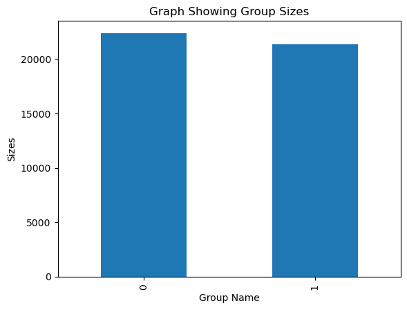

```python
group_sizes = data.groupby("Premium_Delivery").size()
group_sizes.plot(kind='bar')
plt.xlabel('Group Name')
plt.ylabel('Sizes')
plt.title('Graph Showing Group Sizes')
plt.show()
```

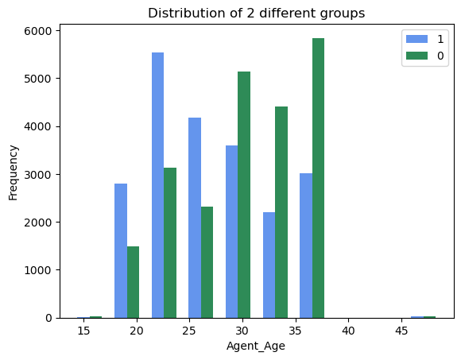

```python
df=data[["Agent_Age","Premium_Delivery"]]
colors = ['purple', 'orange']
group_name = df['Premium_Delivery'].unique()

fig, ax = plt.subplots()

a_heights, a_bins = np.histogram(df[df['Premium_Delivery']==1]['Agent_Age'])
b_heights, b_bins = np.histogram(df[df['Premium_Delivery']==0]['Agent_Age'], bins=a_bins)

width = (a_bins[1] - a_bins[0])/3

ax.bar(a_bins[:-1], a_heights, width=width, facecolor='cornflowerblue')
ax.bar(b_bins[:-1]+width, b_heights, width=width, facecolor='seagreen')
# Add a legend
ax.legend(group_name)

# Add a title and axis label
ax.set_title('Distribution of 2 different groups')
ax.set_xlabel('Agent_Age')
ax.set_ylabel('Frequency')

# Show the plot
plt.show()
```

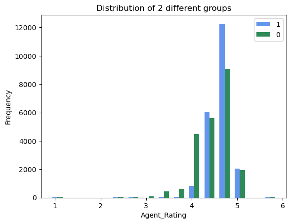

```python
df = data[["Agent_Rating","Premium_Delivery"]]
df = df[~df["Agent_Rating"].isnull()]
colors = ['purple', 'orange']
group_name = df['Premium_Delivery'].unique()

fig, ax = plt.subplots()

a_heights, a_bins = np.histogram(df[df['Premium_Delivery']==1]['Agent_Rating'],bins=15)
b_heights, b_bins = np.histogram(df[df['Premium_Delivery']==0]['Agent_Rating'], bins=a_bins)

width = (a_bins[1] - a_bins[0])/3

ax.bar(a_bins[:-1], a_heights, width=width, facecolor='cornflowerblue')
ax.bar(b_bins[:-1]+width, b_heights, width=width, facecolor='seagreen')
# Add a legend
ax.legend(group_name)

# Add a title and axis label
ax.set_title('Distribution of 2 different groups')
ax.set_xlabel('Agent_Rating')
ax.set_ylabel('Frequency')

# Show the plot
plt.show()
```

```python
df = data[["Distance","Premium_Delivery"]]
data2 = data2[~data2["Distance"].isnull()]
data2[data2["Distance"]>50]
```

|  | Order_ID | Agent_Age | Agent_Rating | Store_Latitude | Store_Longitude | Drop_Latitude | Drop_Longitude | Order_Date | Order_Time | Pickup_Time | Weather | Traffic | Vehicle | Area | Delivery_Time | Category | Premium_Delivery | Distance |
| --- | --- | --- | --- | --- | --- | --- | --- | --- | --- | --- | --- | --- | --- | --- | --- | --- | --- | --- |

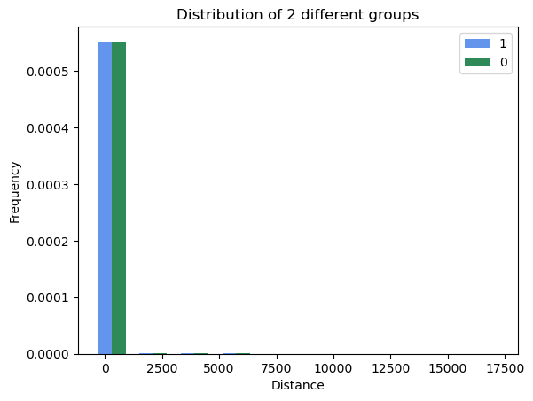

```python
df = data[["Distance","Premium_Delivery"]]
df = df[~df["Distance"].isnull()]
colors = ['purple', 'orange']
group_name = df['Premium_Delivery'].unique()

fig, ax = plt.subplots()

a_heights, a_bins = np.histogram(df[df['Premium_Delivery']==1]['Distance'],bins=10,density=True)
b_heights, b_bins = np.histogram(df[df['Premium_Delivery']==0]['Distance'], bins=a_bins,density=True)

width = (a_bins[1] - a_bins[0])/3

ax.bar(a_bins[:-1], a_heights, width=width, facecolor='cornflowerblue')
ax.bar(b_bins[:-1]+width, b_heights, width=width, facecolor='seagreen')
# Add a legend
ax.legend(group_name)

# Add a title and axis label
ax.set_title('Distribution of 2 different groups')
ax.set_xlabel('Distance')
ax.set_ylabel('Frequency')

# Show the plot
plt.show()
```

Hi ha distancias molt grans i crec que es degut a un error a les dades on les latituds i les longituds de les tendes tenen valors negatius i el desti te un valor d'el mateix ordre pero positiu. Per tant les distancies sagumenten molt, corregirer l'error ja que crec que aquest valors son incorrectes.

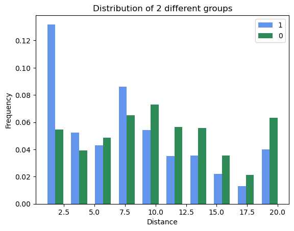

```python
data = pd.read_csv(dataset_path)
data["Premium_Delivery"] = data.apply(lambda x: 1 if x.Delivery_Time<=120  else 0, axis=1)
data["Store_Latitude"] = np.abs(data["Store_Latitude"])
data["Store_Longitude"] = np.abs(data["Store_Longitude"])

from haversine import haversine
data2["Distance"] = data2.apply(lambda x: haversine((x.Store_Latitude,x.Store_Longitude),(x.Drop_Latitude,x.Drop_Longitude)), axis=1)
data = data.drop(columns=['Order_ID', 'Order_Date',"Order_Time","Pickup_Time"])
data = data.drop(columns=['Store_Latitude', 'Store_Longitude',"Drop_Latitude","Drop_Longitude"])
df = data2[["Distance","Premium_Delivery"]]
df = df[~df["Distance"].isnull()]
colors = ['purple', 'orange']
group_name = df['Premium_Delivery'].unique()

fig, ax = plt.subplots()

a_heights, a_bins = np.histogram(df[df['Premium_Delivery']==1]['Distance'],bins=10,density=True)
b_heights, b_bins = np.histogram(df[df['Premium_Delivery']==0]['Distance'], bins=a_bins,density=True)

width = (a_bins[1] - a_bins[0])/3

ax.bar(a_bins[:-1], a_heights, width=width, facecolor='cornflowerblue')
ax.bar(b_bins[:-1]+width, b_heights, width=width, facecolor='seagreen')
# Add a legend
ax.legend(group_name)

# Add a title and axis label
ax.set_title('Distribution of 2 different groups')
ax.set_xlabel('Distance')
ax.set_ylabel('Frequency')

# Show the plot
plt.show()
```

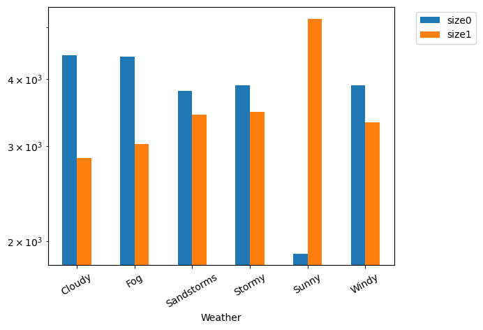

```python
total=data.groupby(by=["Premium_Delivery", "Weather"], as_index=False).size()
no=total[total["Premium_Delivery"]==0][["Weather","size"]]
yes=total[total["Premium_Delivery"]==1][["Weather","size"]]
df=pd.merge(no,yes,on="Weather",suffixes=["0","1"])
ax = df.plot(kind='bar', x='Weather', logy=True, rot=0)
ax.legend(bbox_to_anchor=(1.05, 1), loc='upper left')
plt.xticks(rotation=30)
plt.show()
```

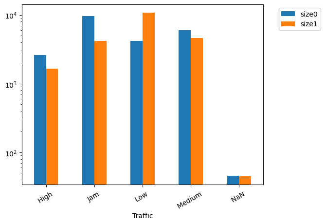

```python
total=data.groupby(by=["Premium_Delivery", "Traffic"], as_index=False).size()
no=total[total["Premium_Delivery"]==0][["Traffic","size"]]
yes=total[total["Premium_Delivery"]==1][["Traffic","size"]]
df=pd.merge(no,yes,on="Traffic",suffixes=["0","1"])
ax = df.plot(kind='bar', x='Traffic', logy=True, rot=0)
ax.legend(bbox_to_anchor=(1.05, 1), loc='upper left')
plt.xticks(rotation=30)
plt.show()
```

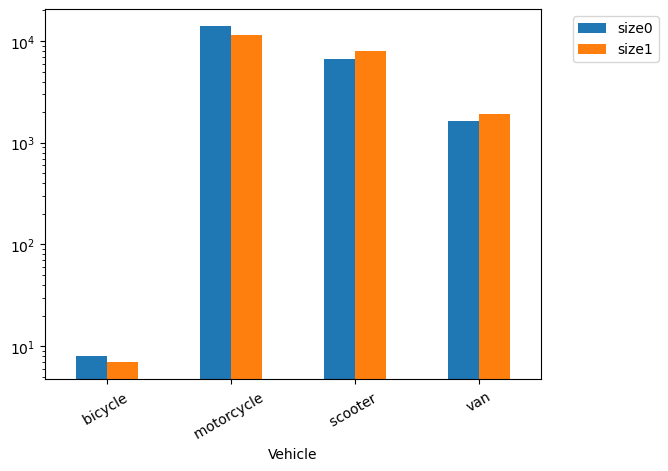

```python
total=data.groupby(by=["Premium_Delivery", "Vehicle"], as_index=False).size()
no=total[total["Premium_Delivery"]==0][["Vehicle","size"]]
yes=total[total["Premium_Delivery"]==1][["Vehicle","size"]]
df=pd.merge(no,yes,on="Vehicle",suffixes=["0","1"])
ax = df.plot(kind='bar', x='Vehicle', logy=True, rot=0)
ax.legend(bbox_to_anchor=(1.05, 1), loc='upper left')
plt.xticks(rotation=30)
plt.show()
```

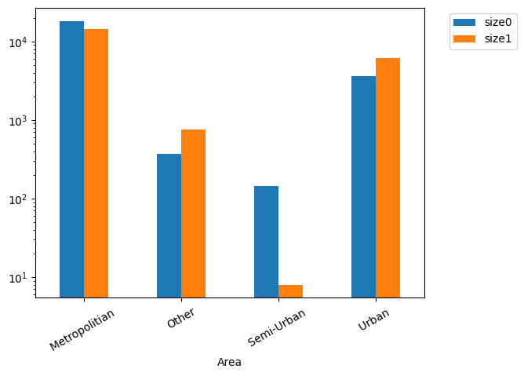

```python
total=data.groupby(by=["Premium_Delivery", "Area"], as_index=False).size()
no=total[total["Premium_Delivery"]==0][["Area","size"]]
yes=total[total["Premium_Delivery"]==1][["Area","size"]]
df=pd.merge(no,yes,on="Area",suffixes=["0","1"])
ax = df.plot(kind='bar', x='Area', logy=True, rot=0)
ax.legend(bbox_to_anchor=(1.05, 1), loc='upper left')
plt.xticks(rotation=30)
plt.show()
```

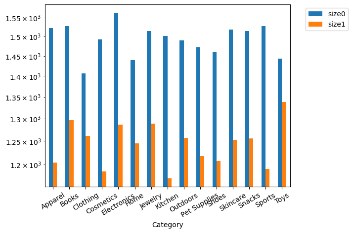

```python
total=data.groupby(by=["Premium_Delivery", "Category"], as_index=False).size()
no=total[total["Premium_Delivery"]==0][["Category","size"]]
yes=total[total["Premium_Delivery"]==1][["Category","size"]]
df=pd.merge(no,yes,on="Category",suffixes=["0","1"])
ax = df.plot(kind='bar', x='Category', logy=True, rot=0)
ax.legend(bbox_to_anchor=(1.05, 1), loc='upper left')
plt.xticks(rotation=30)
plt.show()
```

**Anàlisi:**

1. **Avalua la relació de les freqüències de la variable `Premium_Delivery`:** Reflexiona sobre com es distribueixen les transaccions entre premium i no premium. És la distribució significativament desigual? Què implica això per a l’anàlisi i la modelització de les dades?
2. **Analitza la informació proporcionada pels histogrames de les variables descriptives:** Observa si hi ha diferències notables en les distribucions d’aquestes variables entre les classes. Pregunta’t: Hi ha variables que mostrin patrons diferents per al nivell de servei?
3. **Considera altres formes de visualització:** Podrien ser útils altres tipus de gràfics per entendre millor les dades? Per exemple:
   - **Diagrames de caixa (boxplots):** Podrien ser útils per visualitzar la distribució de les variables en ambdues classes i identificar valors atípics.
   - **Mapa de calor de la matriu de correlació:** Pot ajudar a entendre les relacions entre les variables i identificar possibles agrupacions o dependències entre elles.

Aquest anàlisi t’ajudarà a obtenir una comprensió més profunda de la naturalesa de les teves dades i a identificar possibles característiques que podrien ser importants per detectar les entregues premium.

**Resposta:**

Veiem que la distribució entre premium i no premium es molt similar, això es positiu perque si tinguesim distribucions molt diferents podrien tenir problemes al predir la clasificacio ja que d'una categoria tindriem moltes mes clases i menys de l'altre per tant tendririem a predir millor la que tenim més dades.

Respecte els histogrames sembla que tenim variables que si que afecten a la prediccio com la edad que contra més gran sembla que tendeixen a entregar pitjor o mes lent com a minim, això pot ser per molts motius com que la gent mes jove pren mes ricos i va en moto o bicileta, en canvi la gent mes gran va en cotxe per tant no es pot saltar el trafic, això es nomes una hipotesi pero veiem que clarament hi ha una correlacio. La distribucions respecte el rating contra mes estrekkes sembla que tendeixen a tenir mes entregues premium el qual te sentit ja que la gent valora que les coses arribin en poc temps

Respecte a la distancia com he dit a dalt he cambiat la latitud i la longitud de certes mostres perque estaben en negatiu i crec que no tenien massa sentit ja que no crec que es fesin entregues a milers de km si fem aquests canvis veiem que la distancia esta entre 1-20km. Clarament te sentit que contra mes aprop sigui la entrega mes facil tinguem una entrega premium i veiem clarament que les dades suporten això

Respecte al temps veiem que obviament si no tenim situacions temporals adverses tindriem millores entregues, lo qual te sentit ja que si condiuim en condicions metereologuiques adverses hem d'anar amb mes cura per reduccio de visiblilitat que si conduim amb sol

el veichle sembla que tampoc te molta rellevancia

La zona tampoc sembla que hi ha molta diferencia excepte en semi-urba on tenim que la majoria de entregues son no premium

en tipus de producte veiem que hi ha alguns que tenen tendencia mes a se premium que altres, per exemple joguines tenen molt mes premium que esports.

Respecte a altres modes de visualització crec que els mapes de calor de les matrius de correlacio poden ser molt utils per veure quines variables estan corelacionades perque potser ens dona informació de com dos variables es junten, per exemple l'us de motos en pluja es molt baix i en cas d'utlititzarse el temps tendeix a ser no premium podria ser un resultat que sortis si miresim això

## 2.3. Preprocessament de Dades (1.25 punts)

El preprocessament de dades en ciència de dades és un pas crucial que implica la preparació i transformació de dades brutes en un format adequat per a la seva posterior anàlisi i modelatge. Aquest procés inclou diverses tasques essencials:

1. **Neteja de Dades**: S’eliminen o corregeixen dades errònies, incompletes, inexactes o irrellevants. Això pot incloure tractar amb valors faltants, corregir errors d’entrada i gestionar outliers.
2. **Normalització i Escalat**: Les dades es transformen perquè estiguin en una escala comuna, sense distorsionar diferències en els rangs de valors ni perdre informació. Per exemple, escalat min-max o estandardització.
3. **Codificació de Variables Categòriques**: Les variables categòriques (com gènere o país) es converteixen en formats numèrics perquè puguin ser processades per algorismes d’aprenentatge automàtic, utilitzant tècniques com codificació one-hot o codificació d’etiquetes.
4. **Divisió de Dades**: Les dades es divideixen en conjunts d’entrenament, validació i prova, permetent entrenar models, ajustar hiperparàmetres i avaluar el rendiment del model de manera efectiva.
5. **Gestió de Dades Desbalancejades**: En casos de conjunts de dades desbalancejats, s’apliquen tècniques com sobremostreig o submostreig per assegurar que el model no estigui esbiaixat cap a la classe més freqüent.
6. **Enginyeria de Característiques**: Es creen noves variables (característiques) a partir de les dades existents per millorar la capacitat del model per aprendre patrons i fer prediccions.

El preprocessament és essencial per millorar la qualitat de les dades i fer-les més adequades i efectives per a l’anàlisi i el modelatge en projectes de ciència de dades.

**Implementació:** elimina els atributs categòrics del conjunt de dades i, en el seu lloc, introdueix la transformació d’aquests atributs a tantes variables binàries com categories tinguin. És important que les noves columnes generades siguin de tipus enter. Recorda que la codificació one-hot converteix les etiquetes categòriques en vectors binaris. En aquests vectors, el valor de 1 s’assigna a la posició corresponent a la classe i el valor de 0 a totes les altres posicions. Això facilita que els models d’aprenentatge automàtic processin i entenguin les etiquetes categòriques.

Suggeriment: utilitzeu la funció "get_dummies" de "pandas".

**Solució:**

```python
data_dumied = pd.get_dummies(data, dtype=float)
```

**Implementació:**

A la primera secció de l’exercici vam observar que la columna `Agent_Rating` tenia un nombre reduït de valors nuls. En aquest exercici hem d’imputar els valors nuls pel valor mínim de la columna i verificar que cap columna addicional té valors nuls.

**Solució:**

```python
data_dumied["Agent_Rating"].fillna(data_dumied["Agent_Rating"].min(), inplace = True)
```

```python
data_dumied["Agent_Rating"].isnull().values.any()
```

```
False
```

```python
data_dumied.isnull().values.any()
```

```
False
```

**Implementació:**

Ara dividirem el conjunt de dades. Per fer-ho, segueix aquests passos:

1. Separa els descriptors de la variable resposta. Assigna els descriptors al conjunt `X` i la variable resposta al conjunt `y`.
2. Elimina del conjunt de descriptors la columna `Delivery_Time`, ja que va ser utilitzada per calcular la nostra variable resposta.
3. Divideix el *dataset* en dos subconjunts: un per a entrenament (*train*) i un altre per a proves (*test*). Assigna el 80% de les dades al conjunt d’entrenament (`X_train`, `y_train`) i el 20% al conjunt de proves (`X_test`, `y_test`). Utilitza la funció `train_test_split` de la biblioteca `model_selection` de `sklearn`. Assegura’t d’utilitzar `random_state = 24` i fes una divisió estratificada per mantenir la mateixa proporció de classes en ambdós conjunts.

**Solució:**

```python
y=data_dumied["Premium_Delivery"]
X=data_dumied.drop(columns=['Premium_Delivery',"Delivery_Time" ])
X_train, X_test, y_train, y_test = train_test_split(
    X, y, test_size=0.2, random_state=24)
```

**Implementació:**

1. Normalitza els descriptors utilitzant el `StandardScaler` de `sklearn`. Això estandarditzarà les característiques restant la mitjana i dividint per la desviació estàndard.
2. Mostra les dimensions del conjunt de descriptors original, del conjunt d’entrenament i del conjunt de prova. Això et permetrà veure com s’han dividit les dades.

**Nota:** Ajusta el `StandardScaler` únicament amb els descriptors d’entrenament per evitar la fuga d’informació o 'data leakage'. La fuga d’informació ocorre quan s’utilitza informació del conjunt de prova o validació en el procés d’ajust del model. És a dir, si ajustes el model d’escalat amb tot el conjunt de dades, estaries utilitzant informació del conjunt de prova o validació en l’ajust, fet que podria donar la impressió que el model és més precís del que realment és. Per tant, assegura’t d’ajustar el `StandardScaler` només amb les dades d’entrenament i després aplicar-lo als conjunts d’entrenament i prova.

**Solució:**

```python
object = StandardScaler()
X_train = object.fit_transform(X_train)
X_test = object.transform(X_test)
```

**Implementació:**

Converteix els conjunts de dades d’entrenament i prova en tensors utilitzant el mètode `tensor` de la biblioteca `PyTorch`.

**Solució:**

```python
tensor_x_train = torch.tensor(np.float32(X_train))
tensor_x_test = torch.tensor(np.float32(X_test))
y_train = y_train.to_numpy()
y_train = [[item] for item in y_train]
tensor_y_train = torch.tensor(y_train, dtype=torch.float32)
y_test = y_test.to_numpy()
y_test = [[item] for item in y_test]
tensor_y_test = torch.tensor(y_test, dtype=torch.float32)
```

## 2.4. Modelització (2 punts)

El MLP (Perceptró Multicapa) és, sens dubte, una eina poderosa en el camp de l’aprenentatge automàtic i la intel·ligència artificial. Pot manejar tasques de classificació i regressió, fet que el fa versàtil per a una varietat de problemes. La seva capacitat per modelar relacions no lineals complexes el converteix en una elecció popular quan les dades no segueixen patrons lineals simples.

Aquí hi ha alguns punts clau sobre el MLP:

- **Capes i Neurones**: El MLP consta de múltiples capes de neurones, que inclouen una capa d’entrada, una o més capes ocultes i una capa de sortida. Cada neurona d’una capa està connectada a totes les neurones de la capa següent.
- **Funcions d’Activació**: Per introduir no linealitat en el model, s’utilitzen funcions d’activació a les neurones, com la funció sigmoide, ReLU (Rectified Linear Unit) o tangent hiperbòlica. Aquestes funcions permeten al MLP capturar patrons complexos en les dades.
- **Aprenentatge Supervisat**: L’entrenament del MLP implica ajustar els pesos de les connexions entre neurones per minimitzar la diferència entre les sortides produïdes per la xarxa i les sortides desitjades. Això es fa utilitzant algorismes d’aprenentatge supervisat, com el descens del gradient.
- **Ajust d’Hiperparàmetres**: Igual que altres models d’aprenentatge automàtic, el MLP té hiperparàmetres importants, com el nombre de capes ocultes, el nombre de neurones a cada capa, la funció d’activació i la taxa d’aprenentatge. Sovint, és necessari ajustar aquests hiperparàmetres per obtenir un bon rendiment en una tasca específica.
- **Generalització**: Un dels desafiaments en l’entrenament de MLP és evitar el sobreajustament (overfitting), on el model s’adapta massa a les dades d’entrenament i no generalitza bé a dades noves. La regularització i la validació creuada són tècniques comunes per abordar aquest problema.

En aquest context, el MLP pot ser una excel·lent opció per modelar patrons complexos que indiquin quan una entrega serà premium. No obstant això, és important ajustar i avaluar acuradament el model per garantir que funcioni de manera efectiva en aquesta tasca crítica.

Crear i entrenar un MLP amb diverses capes ocultes amb funció d’activació ReLU és una excel·lent elecció. La funció d’activació ReLU (Rectified Linear Unit) s’utilitza comunament a capes ocultes de xarxes neuronals a causa de la seva capacitat per introduir no linealitat al model, permetent-li aprendre patrons complexos a les dades.

D’altra banda, l’enfocament d’apilar capes lineals utilitzant la classe `Linear` de PyTorch és una forma eficaç i senzilla de construir models de xarxes neuronals.

```python
def train_model(model, X_train, y_train, X_val, y_val, n_epochs, batch_size):
    batch_start = torch.arange(0, len(X_train), batch_size)
    optimizer = optim.Adam(model.parameters(), lr=0.0001)
    loss_fn = nn.BCELoss()

    best_acc = - np.inf
    best_weights = None

    train_loss_hist = []
    train_acc_hist = []
    val_f1_hist = []
    val_accbin_hist = []
    val_aroc_hist = []
    val_loss_hist = []
    val_acc_hist = []

    for epoch in range(n_epochs):
        epoch_loss = []
        epoch_acc = []
        model.train()

        with tqdm.tqdm(batch_start, unit="batch", mininterval=0, disable=True) as bar:
            bar.set_description(f"Epoch {epoch}")
            for start in bar:

                # take a batch
                X_batch = X_train[start:start+batch_size]
                y_batch = y_train[start:start+batch_size]

                # forward pass
                y_pred = model(X_batch)
                loss = loss_fn(y_pred, y_batch)

                # backward pass
                optimizer.zero_grad()
                loss.backward()

                # update weights
                optimizer.step()

                # compute and store metrics

                acc = (y_pred.round() == y_batch).float().mean()
                epoch_loss.append(float(loss))
                epoch_acc.append(float(acc))
                bar.set_postfix(
                    loss=float(loss),
                    acc=float(acc)
                )

        # Evaluating the model at the end of each epoch
        model.eval()
        y_pred = model(X_val)
        ce = float(loss_fn(y_pred, y_val))
        acc = float((y_pred.round() == y_val).float().mean())
        accbin = binary_accuracy(torch.squeeze(y_pred), torch.squeeze(y_val))
        f1 = binary_f1_score(torch.squeeze(y_pred), torch.squeeze(y_val))
        aroc = binary_auroc(torch.squeeze(y_pred), torch.squeeze(y_val))
        train_loss_hist.append(np.mean(epoch_loss))
        train_acc_hist.append(np.mean(epoch_acc))
        val_loss_hist.append(ce)
        val_acc_hist.append(acc)
        val_accbin_hist.append(accbin)
        val_aroc_hist.append(aroc)
        val_f1_hist.append(f1)

        if acc > best_acc:
            best_acc = acc
            best_weights = copy.deepcopy(model.state_dict())
        # print(f"Epoch {epoch} validation: Cross-entropy={ce:.2f}, Accuracy={acc*100:.1f}%")

    model.load_state_dict(best_weights)
    return best_acc, train_loss_hist, val_loss_hist, train_acc_hist, val_acc_hist,val_f1_hist,val_aroc_hist,val_accbin_hist
```

**Implementació:**

La modelització del MLP la realitzarem amb la biblioteca `PyTorch`. Per fer-ho:

1. Comença creant el model `BinaryServiceLevel`, per al qual és necessari crear una classe que hereti de `nn.Module`.
2. Al constructor (`__init__`), declara les següents capes:
   - Una capa lineal `nn.Linear` d’entrada amb una mida de sortida de 19, i una funció d’activació ReLU `nn.ReLU`.
   - Una capa lineal `nn.Linear` amb una mida de sortida de 19, i una funció d’activació ReLU `nn.ReLU`.
   - Una capa lineal `nn.Linear` de sortida amb una funció d’activació Sigmoid `nn.Sigmoid`.
3. Després, al mètode `forward` enllaça les diferents capes i les seves respectives funcions d’activació en l’ordre definit en el punt anterior.
4. No oblidis mostrar el nombre de paràmetres utilitzant el mètode `.parameters()` del model.

```python
class BinaryServiceLevelBase(nn.Module):
    def __init__(self):
        super().__init__()
        self.fc1 = nn.Linear(37,19)
        self.relu1 = nn.ReLU()
        self.fc2 = nn.Linear(19,19)
        self.relu2 = nn.ReLU()
        self.fc3 = nn.Linear(19,1)
        self.sig3 = nn.Sigmoid()
    def forward(self, x):
        x = self.fc1(x)
        x = self.relu1(x)
        x = self.fc2(x)
        x = self.relu2(x)
        x = self.fc3(x)
        x = self.sig3(x)
        return x
```

**Solució:**

```python
model = BinaryServiceLevelBase()
for param in model.parameters():
    print(type(param.data), param.size())
```

```
<class 'torch.Tensor'> torch.Size([19, 37])
<class 'torch.Tensor'> torch.Size([19])
<class 'torch.Tensor'> torch.Size([19, 19])
<class 'torch.Tensor'> torch.Size([19])
<class 'torch.Tensor'> torch.Size([1, 19])
<class 'torch.Tensor'> torch.Size([1])
```

**Implementació:**

1. Ara és el moment d’entrenar i validar el model aplicant validació creuada utilitzant `StratifiedKFold` sobre el conjunt d’entrenament, amb un valor de k = 5 i `shuffle = True`.
2. En cada divisió (split), el model s’ha d’entrenar utilitzant la funció `train_model`. Assegura’t d’entrenar amb les dades d’entrenament i validació de cada divisió, establint el nombre d’èpoques en 15 i la mida del lot en 32.
3. En cada iteració s’han de calcular les següents mètriques:
   - Calcula l’exactitud (*accuracy*) per mesurar la precisió de les prediccions.
   - Calcula el valor F1, que és una mesura que combina precisió i sensibilitat.
   - Calcula l’àrea sota la corba ROC (AUC-ROC) per avaluar el rendiment del model en la classificació binària.
4. Finalment, s’ha de mostrar la mitjana de cadascuna de les mètriques calculades en el punt anterior.

**Solució:**

```python
input = torch.tensor([[0], [1], [0.7], [0.6]])
target = torch.tensor([[0], [1], [1], [0]])
binary_f1_score(torch.squeeze(input), torch.squeeze(target))
```

```
tensor(0.8000)
```

```python
skf=StratifiedKFold(n_splits=5, shuffle=True)
lst_accu_stratified = []
for train_index, test_index in skf.split(tensor_x, tensor_y):
    x_train_fold, x_test_fold = tensor_x[train_index], tensor_x[test_index]
    y_train_fold, y_test_fold = tensor_y[train_index], tensor_y[test_index]
    results = train_model(model, x_train_fold, y_train_fold, x_test_fold, y_test_fold, n_epochs=15, batch_size=32)
    lst_accu_stratified.append(results)
```

```python
folds = len(lst_accu_stratified)
medacc = 0
medf1 = 0
medroc = 0
for i in range(folds):
    print("La accuracy de la fold "+ str(i)+ " es: ")
    print(np.mean(lst_accu_stratified[i][-1]))
    medacc += np.mean(lst_accu_stratified[i][-1])
    print("El valor F1 de la fold "+ str(i)+ " es: ")
    print(np.mean(lst_accu_stratified[i][-3]))
    medf1 += np.mean(lst_accu_stratified[i][-3])
    print("L’àrea sota la corba ROC de la fold "+ str(i)+ " es: ")
    print(np.mean(lst_accu_stratified[i][-2]))
    medroc += np.mean(lst_accu_stratified[i][-2])

medacc = medacc/folds
medf1 = medf1/folds
medroc = medroc/folds
print("La mitjana de la accuracy es: ")
print(medacc)
print("La mitjana de la f1 es: ")
print(medf1)
print("La mitjana de l’àrea sota la corba ROC es: ")
print(medroc)
```

```
La accuracy de la fold 0 es:
0.7710149
El valor F1 de la fold 0 es:
0.7635444
L’àrea sota la corba ROC de la fold 0 es:
0.8661942520096724
La accuracy de la fold 1 es:
0.78270936
El valor F1 de la fold 1 es:
0.7753849
L’àrea sota la corba ROC de la fold 1 es:
0.8804551727429148
La accuracy de la fold 2 es:
0.7784414
El valor F1 de la fold 2 es:
0.7744852
L’àrea sota la corba ROC de la fold 2 es:
0.8826018911243717
La accuracy de la fold 3 es:
0.7836905
El valor F1 de la fold 3 es:
0.77797943
L’àrea sota la corba ROC de la fold 3 es:
0.8836666455292378
La accuracy de la fold 4 es:
0.7967895
El valor F1 de la fold 4 es:
0.7956743
L’àrea sota la corba ROC de la fold 4 es:
0.8913230472502166
La mitjana de la accuracy es:
0.7825291514396667
La mitjana de la f1 es:
0.7774136424064636
La mitjana de l’àrea sota la corba ROC es:
0.8808482017312826
```

**Anàlisi:**

1. Realitza una anàlisi dels resultats i decideix si consideres que aquest model és acceptable.
2. Avalua quina de les mesures de rendiment utilitzades és la més apropiada.
3. Examina la distribució de les classes i planteja una estratègia, si és necessari, per assegurar la fiabilitat de l’estudi realitzat.

En aquest cas com no tenim un interes especial en evitar els FP o FN ja que ningun dels dos es molt mes prioritari d'evitar (no estem analitzant si te o no cancer on els FN poden ser mortals), crec que amb la F1 podem fer suficient, l'unic que podriem fer es mirar quin threshold dona millors resultats ja que l'area sobre la corba roc es molt completa per tant podriem obtenir una millor f1 simplement ajustant el threshold pel qual donem positius

**Resposta:**

**Implementació:**

Ara és el moment d’analitzar la fase d’entrenament. Per fer-ho:

1. Divideix el conjunt d’entrenament en dos subconjunts: un per a entrenament (train) i un altre per a validació (val), assignant el 80% de les dades al conjunt d’entrenament.
2. Entrena el model amb la funció `model_train`, guardant tots els paràmetres que retorna.
3. Crea gràfics que mostrin la pèrdua (`loss`) tant en l’entrenament com en la validació al llarg de les èpoques.
4. Finalment, genera gràfics que representin l’exactitud (`accuracy`) en l’entrenament i la validació al llarg de les èpoques.

**Solució:**

```python
 results = train_model(model, tensor_x_train, tensor_y_train, tensor_x_test, tensor_y_test, n_epochs=100, batch_size=32)
```

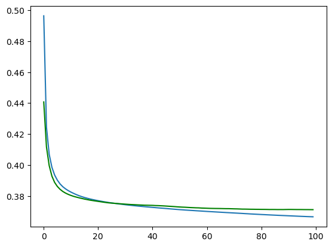

```python
plt.plot(results[1])
plt.plot(results[2],color='green')
## or plot only the first velocity
#plt.plot(vels[0]

plt.show()
```

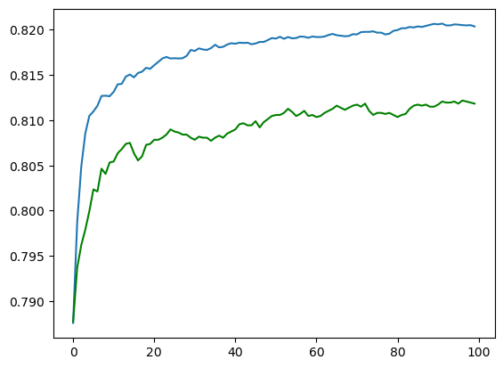

```python
plt.plot(results[3])
plt.plot(results[4], color='green')


plt.show()
```

**Anàlisi:**

Quines conclusions pots obtenir de les gràfiques tant de la pèrdua (`loss`) com de l’exactitud (`accuracy`) en l’entrenament i la validació al llarg de les èpoques?

**Resposta:**

Veiem com tant la loss com la accuracy en train es millor que en test, lo qual es evident ja que s'ajustara més a dades que ja ha vist que a dades que encara no ha vist pero no estem perdent massa, també veiem com les dos grafiques se estan estabilitzant per tant fer més epoch no ajudaria massa ja que sembla que ha arribat a una asimptota i no progresara més que això per tant dedicar més recursos a entrenar es no es prodoctiu, inclus podria empitjorar el model si s'adaptes mes a les dades de entrenament i perdes generalitat

**Implementació:**

És hora d’avaluar el rendiment del model en el conjunt de prova. Per fer-ho:

1. Realitza la predicció sobre el conjunt de prova.
2. Calcula les mètriques dels apartats anteriors: exactitud (accuracy), F1 score i corba ROC.

**Solució:**

```python
y_pred = model(tensor_x_test)
y_val = tensor_y_test
accbin = binary_accuracy(torch.squeeze(y_pred), torch.squeeze(y_val))
f1 = binary_f1_score(torch.squeeze(y_pred), torch.squeeze(y_val),threshold=0.474)
aroc = binary_auroc(torch.squeeze(y_pred), torch.squeeze(y_val))
print("La accuracy  es: ")
print(accbin)

print("El valor F1  es: ")
print(f1)

print("L’àrea sota la corba ROC  es: ")
print(aroc)
```

```
La accuracy  es:
tensor(0.8122)
El valor F1  es:
tensor(0.8180)
L’àrea sota la corba ROC  es:
tensor(0.9102, dtype=torch.float64)
```

**Implementació:**

Per analitzar el model entrenat, ens basarem en els [Shapley values](https://en.wikipedia.org/wiki/Shapley_value), que introdueixen l’explicació de models d’aprenentatge automàtic. L’objectiu és explicar la predicció d’un model calculant la contribució de cada característica a la predicció. La descripció tècnica del concepte de SHAP és el càlcul dels valors de Shapley a partir de la teoria de jocs. En poques paraules, els valors de Shapley són un mètode per mostrar l’impacte relatiu de cada característica (o variable) que estem mesurant en el resultat final del model d’aprenentatge automàtic, comparant l’efecte relatiu de les entrades amb la mitjana.

Per calcular els *shap values*:

1. Selecciona una mostra de 10000 registres del conjunt d’entrenament.
2. Inicialitza l’'explainer' `shap.DeepExplainer` amb el model entrenat i la mostra anterior.
3. Selecciona una mostra de 400 registres del conjunt d’entrenament.
4. Calcula els *shap values* utilitzant la mostra anterior.
5. Defineix i mostra un DataFrame amb tres columnes:
   - Mitjana aritmètica del valor absolut dels valors.
   - Desviació típica del valor absolut dels valors.
   - Nom de l’atribut descriptiu.
6. Mostra la representació gràfica dels valors utilitzant la biblioteca SHAP.

**Solució:**

```python
sub_train = tensor_x_train[0:1000]
sub_test = tensor_x_test[0:400]
e = shap.DeepExplainer(model, sub_train)
shap_values = e.shap_values(sub_test)
```

```python
df = pd.DataFrame()
df['Nom'] = pd.Series(X.columns)
df['Mitjana aritmètica'] = pd.Series(pd.DataFrame(shap_values.squeeze()).mean())
df['Desviació típica'] = pd.Series(pd.DataFrame(np.abs(shap_values.squeeze())).std())
df
```

|  | Nom | Mitjana aritmètica | Desviació típica |
| --- | --- | --- | --- |
| 0 | Agent_Age | 0.005886 | 0.079798 |
| 1 | Agent_Rating | 0.002367 | 0.095752 |
| 2 | Weather_Cloudy | -0.000833 | 0.085644 |
| 3 | Weather_Fog | 0.014393 | 0.071358 |
| 4 | Weather_Sandstorms | -0.002220 | 0.026287 |
| 5 | Weather_Stormy | -0.003464 | 0.027285 |
| 6 | Weather_Sunny | 0.000908 | 0.035181 |
| 7 | Weather_Windy | -0.003943 | 0.036486 |
| 8 | Traffic_High | -0.000889 | 0.050627 |
| 9 | Traffic_Jam | -0.027314 | 0.090192 |
| 10 | Traffic_Low | -0.013461 | 0.045163 |
| 11 | Traffic_Medium | 0.004667 | 0.057621 |
| 12 | Traffic_NaN | -0.000720 | 0.027461 |
| 13 | Vehicle_bicycle | 0.000000 | 0.000000 |
| 14 | Vehicle_motorcycle | -0.005010 | 0.041692 |
| 15 | Vehicle_scooter | 0.001640 | 0.023052 |
| 16 | Vehicle_van | 0.000492 | 0.024784 |
| 17 | Area_Metropolitian | -0.001291 | 0.031298 |
| 18 | Area_Other | 0.000465 | 0.005820 |
| 19 | Area_Semi-Urban | -0.001560 | 0.038150 |
| 20 | Area_Urban | 0.000406 | 0.011130 |
| 21 | Category_Apparel | 0.002271 | 0.057405 |
| 22 | Category_Books | 0.000207 | 0.061612 |
| 23 | Category_Clothing | -0.005156 | 0.067004 |
| 24 | Category_Cosmetics | 0.005938 | 0.046970 |
| 25 | Category_Electronics | 0.001328 | 0.046440 |
| 26 | Category_Grocery | 0.008900 | 0.125103 |
| 27 | Category_Home | 0.001208 | 0.058953 |
| 28 | Category_Jewelry | 0.000167 | 0.057977 |
| 29 | Category_Kitchen | -0.007420 | 0.076200 |
| 30 | Category_Outdoors | -0.000792 | 0.061046 |
| 31 | Category_Pet Supplies | 0.004096 | 0.058490 |
| 32 | Category_Shoes | 0.000091 | 0.059663 |
| 33 | Category_Skincare | 0.001369 | 0.060994 |
| 34 | Category_Snacks | -0.007345 | 0.069215 |
| 35 | Category_Sports | 0.003024 | 0.056357 |
| 36 | Category_Toys | 0.002539 | 0.051460 |

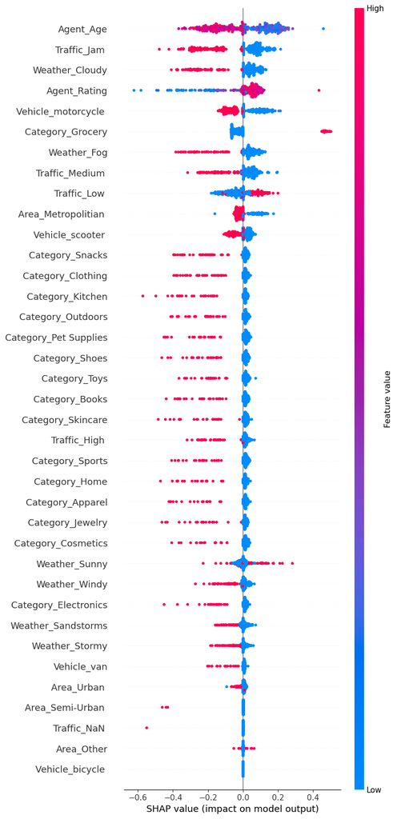

```python
shap.summary_plot(shap_values.squeeze(),sub_test, feature_names = X.columns ,max_display=X.shape[1])
```

**Anàlisi:**

Relaciona la interpretació dels *shap values* amb l’anàlisi exploratori de les dades realitzat a l’exercici 2.2.

**Resposta:**

**Anàlisi:**

Imagina que calculem els *shap values* per a cada divisió (split) en l’exercici en què vam entrenar el model utilitzant validació creuada.

- Els anàlisis dels diferents models haurien de ser similars? Per què o per què no?
- Què indicaria si l’anàlisi de cada model varia molt d’un a l’altre?
- Quins usos addicionals podem donar als *shap values*?

**Resposta:**

En general crec que si ja que les variables les quals aporten més al model haurien de ser les mateixes sense tenir en compte la submostra de les dades. Això podria pasar per diversos motius, un es que les submostres que agafem per fer el split no estiguin ven repartides, amb això vull dir que pot ser agafem nomes els repartidos tenen més de 30 anys i per tant sembla que la edad es molt menys important, per evitar això ens hauriem d'assegurar que les submostres fosin prou aleatories i estiguesin ben repartides. Un altre posible problema es que el model no estigui ven entrenat, per exemple si agafem i fem nomes 1 epoch pot ser no ha tingut temps de decidir quins hyperparametres son els que ajuden a predir i com començen amb dades diferents han arribats a llocs molt diferents, si els deixesim treballar als dos mes epoch haurien d'arribar a la mateixa zona pero amb una sola ireracio podem veure aquest comportament.

Podriem utilitzar els shap values per trobar variables que no estan aportant informacio al model per eliminar-les per optimitzar el model, ja que tenir variables que no aporten informació farà que sigui computacionalment més complex sense cap benefici pel model.